# Bikesharing Capstone Project

Voor dit onderzoek heb ik de volgende packages gebruikt:

- `tidyverse`
- `scales` (opmaak getallen)
- `skimr` (samenvatting dataset)
- `stringi` (tekst manipulatie)
- `ggrepel` (overlappende tekstlabels)
- `OpenStreetMap` (plotten op kaarten)
- `openlayers` (plotten op kaarten)
- `leaflet` (plotten op kaarten)
- `leaflet.providers` (plotten op kaarten)
- `RColorBrewer` (aangepaste kleurenpaletten)
- `viridis` (kleurenblind-vriendelijke kleurenpaletten)

# Onderzoeksopdracht

In deze opdracht is het mijn taak om de volgende vraag te beantwoorden:

*How do annual members and casual riders use Cyclistic bikes differently?*

Oftewel, kan ik uit de gegevens, verschillen ontwaren tussen gelegenheidsgebruikers (**casuals**) en gebruikers met een jaarabonnement (**members**)? In het vervolg zal ik zoveel mogelijk de termen casual(s) en member(s) gebruiken om respectievelijk gelegenheidsgebruikers en jaarabonnees aan te duiden.

Verder is mij opgedragen om de volgende zaken te leveren:

1. A clear statement of the business task

2. A description of all data sources used

3. Documentation of any cleaning or manipulation of data

4. A summary of your analysis

5. Supporting visualizations and key findings

6. Your top three recommendations based on your analysis

# Ask

In deze fase moet duidelijk worden wat het probleem is dat ik moet oplossen en hoe mijn inzichten zakelijke beslissingen kunnen sturen.

## Onderzoeksvraag

De eerste taak is om duidelijk te krijgen wat er precies gevraagd wordt. We beginnen met de **onderzoeksvraag**:

· *How do annual members and casual riders use Cyclistic bikes differently?*

· *(NL) Hoe verschilt het fietsgebruik tussen jaarleden en gelegenheidsrijders?*

### Definities annual members en casual riders

Om de onderzoeksvraag goed te begrijpen moet eerst duidelijk zijn wat men verstaat onder jaarleden en gelegenheidsrijders.

| **Begrip** | **Definitie** |
| --- | --- |
| **Jaarleden** (annual members) | Gebruikers die een jaarabonnement bij Cyclistic hebben aangeschaft. |
| **Gelegenheidsrijders** (casual riders) | Gebruikers die een enkele rit aanschaffen, of een dagpas. |

### Stakeholders

Wie zijn de stakeholders en wat willen ze?

**De stakeholders:**

**Wat willen deze stakeholders?**

| Stakeholder | Omschrijving |
| --- | --- |
| **Directeur marketing** | De direct leidinggevende in deze casus |
| **Directieteam** | De bedrijfsleiding |

De **directeur marketing** is er van overtuigt dat het toekomstige succes van het bedrijf afhankelijk is van het maximaliseren van het aantal mensen dat een jaarabonnement afsluit bij Cyclistic.

Om dat doel te bereiken wil men weten wat het verschil is tussen jaarleden en gelegenheidsgebruikers. Zodat de afdeling Marketing een strategie kan ontwikkelen om het aantal jaarleden te vergroten, om zodoende het toekomstige succes van het bedrijf te waarborgen.

De directeur marketing wil het aantal jaarleden vergroten omdat deze leden veel winstgevender zijn dan de gelegenheidsgebruikers. Omdat hij verwacht dat gelegenheidsgebruikers meer geneigd zijn om jaarleden te worden dan nieuwe gebruikers, wil hij de aandacht van een marketingcampagne richten op gelegenheidsgebruikers, in plaats van het hele spectrum aan mogelijke nieuwe klanten.

Het **directieteam** moet voorstellen voor deze nieuwe strategie goedkeuren.

## Business task:

Het onderzoek is er dus op gericht om verschillen in het gebruik van fietsen te ontdekken, tussen jaarleden en mensen die een fiets voor een enkele rit of een dag huren. Om zodoende een deel van de informatiepuzzel te leggen om gelegenheidsgebruikers te verleiden tot het afsluiten van een jaarabonnement.

# Prepare

Om de onderzoeksvraag, *hoe verschilt het fietsgebruik tussen jaarleden (**members**) en gelegenheidsrijders (**casuals**),* te beantwoorden gebruik ik gegevens van Lyft Bikes and Scooters, LLC (Bikeshare), opererend onder de naam *Divvy bicycle sharing service* in Chicago (VS). Ik gebruik de gegevens van juni 2022 tot en met mei 2023. In totaal gaat het om 12 maanden aan gegevens.

De gegevens zijn te downloaden via:

https://divvy-tripdata.s3.amazonaws.com/index.html

## Kan ik met deze data mijn onderzoeksvraag beantwoorden?

Daarvoor moet eerst duidelijk zijn welke gegevens ik tot mijn beschikking heb. Daarvoor moet ik de gegevens importeren in R. Met deze code combineer ik in één keer alle 12 csv bestanden tot één tabel en voeg ik een tijdsformat toe aan de started_at en ended_at kolommen:

```r
# Set the working directory
setwd("D:/Users/username/Documents/Data Analytics/Capstone Project/Case study Bikes/Dataset")

# Get the file names
files_bikes <- list.files(pattern = "*.csv")

# Read in the files
data_bikes <- lapply(files_bikes, function(x) {
  read_csv(x, col_types = cols(started_at = col_datetime(format = "%Y-%m-%d %H:%M:%S"),
                               ended_at = col_datetime(format = "%Y-%m-%d %H:%M:%S")))
})

# Combine the data into a single data frame
bikes_df <- do.call(rbind, data_bikes)
```

Vervolgens maak ik een samenvatting van de gegevens die ik naar een tekstbestand exporteer:

```r
# Run the summary function and capture the output as text
output_text <- capture.output(summary(bikes_df))

# Save the output as a table
write.table(output_text, file = "output_table.txt", sep = "\t", row.names = FALSE)
```

Uit deze samenvattende gegevens blijkt dat er 5.829.030 rijen en 13 kolommen in het bestand staan. Voor de analyse staan er een aantal relevante variabelen in het bestand die gebruikt kunnen worden. Zoals:

- **ride_id**
  - Uniek identificatienummer waarmee het aantal ritten per station, periode, etc. te berekenen is.
- **rideable_type**
  - Om verschillen in gebruik van fietstype (elektrisch, conventioneel, e.d.) tussen gelegenheidsgebruikers (casuals) en jaarabonnees (members) waar te nemen.
- **station_id**
  - Om verschillen in gebruik van stations tussen gelegenheidsgebruikers (casuals) en jaarabonnees (members) waar te nemen.
- **member_casual**
  - De informatie in deze kolom maakt duidelijk wie - member of casual - de fiets heeft gehuurd. Met deze informatie kan op member en casual gegroepeerd en gefilterd worden.
- **started_at** en **ended_at**
  - Tijdstip en datum waarop rit begon en eindigde. Bruikbaar om variaties in uren, weekdagen, maanden, waar te nemen. En om reistijden ten opzichte van allerlei variabelen te vergelijken. Zoals reistijd per casual/abonnee, of per uur van de dag, weekdag, maand, etcetera.
- **latitude** en **longitude**
  - Lengte- en breedtegraden, die samen de coördinaten vormen. Bruikbaar om gegevens op een kaart te plotten.

Verder zijn er 3 variaties binnen de ‘rideable_type’ (het type fiets)

```r
unique(bikes_df$rideable_type)
```

```
[1] "classic_bike"  "electric_bike" "docked_bike"
```

Tot slot lijkt er een probleempje met de stationsnamen te zijn. Er zijn meer unieke stationsnamen dan dat er stations_id’s zijn. Dit heb ik vastgesteld met behulp van de `skim_without_charts` functie. Het lijkt erop dat er verschillende schrijfwijzen gehanteerd zijn per stations_id. Als ik wil weten welke stations het populairste zijn, dan moet ik deze schrijfwijzen even wijzigen, zodat ze uniform zijn. Dit zal ik later doen.

## Does the data ROCCC?

Goede data voldoet aan de ROCCC standaard.

**Reliable**

De gegevens zijn afkomstig uit een publiek dataset, dat gegevens bevat van Divvy Bikes in Chicago. Als er geen of weinig meetfouten in de data zitten, dan zijn de gegevens voor het bedrijf zelf betrouwbaar. Dit soort data staat ook bekend als ‘primary data’. Dit zijn data die door de onderzoekers (of in dit geval het bedrijf) zelf is verzameld.

Dit zijn positieve aspecten ten aan zijn van de betrouwbaarheid.

**Original**

Aangezien het bedrijf zelf zijn gegevens vastlegt, hebben we gelijk de brondata te pakken. Er zit geen derde partij tussen die de gegevens meet, eventueel bewerkt, en dan aan derden ter beschikking stelt. Technisch gezien is dit wel het geval, aangezien wij dit uit derdehand krijgen. Maar voor deze casus, doe ik alsof ik een werknemer van Divvy Bikes ben.

**Comprehensive (uitgebreid, volledig)**

**Current (actueel)**

De data zijn niet gedateerd, aangezien dit gegevens zijn van de laatste 12 maanden die beschikbaar zijn. In dit geval van juni 2022 tot en met mei 2023. In de skim_without_charts tabel is nog wel een maximale ended_at (onder variable type POSIXct) datum van 7 juni 2023 te zien. Waarschijnlijk doordat een fiets niet tijdig is teruggebracht, of voor langere tijd is gehuurd. De started_at tijden vallen wel binnen de 12-maands periode.

Er is dus sprake van data die actueel zijn

**Cited (geciteerd)**

De bron van de data is https://divvy-tripdata.s3.amazonaws.com/index.html.

Deze data zijn beschikbaar gesteld via een licentie die verleend is door Motivate International Inc: https://www.divvybikes.com/data-license-agreement.

Elke maand wordt er nieuwe data toegevoegd. Daarmee zijn de data actueel. Het overkoepelende bedrijf is Lyft. Volgens Sustainalytics[1] heeft het een gemiddelde ESG risico score (https://www.sustainalytics.com/esg-rating/lyft-inc/2001446317).

[1] Sustainalytics is a company that rates the sustainability of listed companies based on their environmental, social and corporate governance (ESG) performance¹. It is a global leader in ESG research and data, serving the world’s leading institutional investors and corporations.

Bron: Gesprek met Bing, 13-7-2023

### Conclusie

Op het oog zijn er genoeg gegevens om eventuele verschillen tussen de twee gebruikersgroepen waar te nemen.

# Process

In deze fase zal ik de volgende taken doorlopen:

- Beschrijven welke analysetools ik zal gebruiken.
- De data op fouten controleren, eventuele correcties doorvoeren en dit beschrijven.
- Indien nodig, de data transformeren ten behoeve van verdere analyse en visualisatie.

## Keuze voor analysetool (R Notebook)

Voor mijn analyse kies ik voor een R Notebook. Omdat R beter om kan gaan met dit omvangrijke dataset dan Excel, en meer visualisatie mogelijkheden biedt dan SQL. In feite kan R alle stappen uit het analyseproces uitvoeren. Daarnaast is het een mooie manier om te leren hoe je een onderzoeksvraag kunt beantwoorden in R. Ook ben ik al erg bekend met Excel en is het in die zin ook minder leerzaam. En in principe biedt R meer mogelijkheden, als je ze weet te benutten. Dat gaan we in het vervolg uitvinden.

## Data cleaning

De eerste stap is om alle rijen te verwijderen die N/A waarden bevatten. Zodat bij verdere analyse nog steeds appels met appels vergeleken worden. Er is immers niet bekend of de N/A waarden gelijk verdeeld zijn over bijvoorbeeld alle station_id’s (~15% van de station_id’s ontbreekt), terwijl alle ride_id’s en datums wel compleet zijn. Dus als we in de ene analyse alle ride_id’s meenemen, en vervolgens in de volgende stap van de analyse naar station_id’s willen kijken, weten we niet of de verschillen veroorzaakt zijn door het ontbreken van bepaalde station_id’s.

Het verwijderen van alle N/A waarden uit alle rijen gaat als volgt:

```r
bikes_df <- na.omit(bikes_df)
```

Een nieuwe samenvatting van de gegevens is hieronder weergegeven. Er blijven nog 4.494.681 observaties over. Ongever 4,5 miljoen.

```r
skim_without_charts(bikes_df_new)
```

```
── Data Summary ────────────────────────
                           Values
Name                       bikes_df_new
Number of rows             4494681
Number of columns          15
_______________________
Column type frequency:
  character                8
  difftime                 1
  numeric                  4
  POSIXct                  2
________________________
Group variables            None
```

|  | skim_variable | n_missing | complete_rate | min | max | empty | n_unique | whitespace |
| --- | --- | --- | --- | --- | --- | --- | --- | --- |
| 1 | ride_id | 0 | 1 | 16 | 16 | 0 | 4494681 | 0 |
| 2 | rideable_type | 0 | 1 | 11 | 13 | 0 | 3 | 0 |
| 3 | start_station_name | 0 | 1 | 7 | 53 | 0 | 1490 | 0 |
| 4 | start_station_id | 0 | 1 | 3 | 35 | 0 | 1420 | 0 |
| 5 | end_station_name | 0 | 1 | 3 | 64 | 0 | 1777 | 0 |
| 6 | end_station_id | 0 | 1 | 3 | 36 | 0 | 1424 | 0 |
| 7 | member_casual | 0 | 1 | 6 | 6 | 0 | 2 | 0 |
| 8 | weekday | 0 | 1 | 6 | 9 | 0 | 7 | 0 |

|  | skim_variable | n_missing | complete_rate | min | max | median | n_unique |
| --- | --- | --- | --- | --- | --- | --- | --- |
| 1 | ride_duration | 0 | 1 | -168.7 mins | 32035.45 mins | 10.15 mins | 19381 |

|  | skim_variable | n_missing | complete_rate | mean | sd | p0 | p25 | p50 | p75 | p100 |
| --- | --- | --- | --- | --- | --- | --- | --- | --- | --- | --- |
| 1 | start_lat | 0 | 1 | 41.90167 | 0.04289068 | 41.6485 | 41.88096 | 41.89675 | 41.92877 | 42.06486 |
| 2 | start_lng | 0 | 1 | -87.64504 | 0.02510315 | -87.8400 | -87.65840 | -87.64197 | -87.62867 | -87.52531 |
| 3 | end_lat | 0 | 1 | 41.90195 | 0.07056697 | 0.0000 | 41.88103 | 41.89695 | 41.92889 | 42.06485 |
| 4 | end_lng | 0 | 1 | -87.64514 | 0.11962933 | -87.8400 | -87.65862 | -87.64288 | -87.62872 | 0.00000 |

|  | skim_variable | n_missing | complete_rate | min | max | median | n_unique |
| --- | --- | --- | --- | --- | --- | --- | --- |
| 1 | started_at | 0 | 1 | 2022-06-01 00:00:04 | 2023-05-31 23:59:49 | 2022-09-21 14:54:13 | 3905887 |
| 2 | ended_at | 0 | 1 | 2022-06-01 00:02:38 | 2023-06-07 23:04:26 | 2022-09-21 15:09:23 | 3919337 |

### Station_id’s met dubbele namen

Om erachter te komen welke stations dubbele namen hebben, gebruik ik een stuk code om alle station_id’s die meer dan één keer voorkomen op te slaan in een nieuw data frame. Dit nieuwe data frame draagt de naam “double_station_names”.

```r
# Toon alle unieke combinaties van start_station_id en start_station_name
# Hiermee zie alle verschillende namen die een start_station_id heeft
double_start_stations <- bikes_df %>%
  group_by(start_station_id) %>%
  filter(n_distinct(start_station_name) > 1) %>%
  select(start_station_id, start_station_name) %>%
  distinct()
```

Bovenstaande code genereert een nieuw data frame. Dit data frame bevat alle unieke start_station_id’s die een start_station_name hebben met verschillende schrijfwijzen.

Hoeveel start_station_id’s zijn dit in totaal? Dit waren er 299. Om een indruk te krijgen hoe de tabel eruitziet met 299 unieke start_station_id’s, gebruikte ik de onderstaande code.

```r
# De tabel met dubbele namen ziet er ongeveer zo uit:
double_start_stations %>%
  arrange(start_station_id) %>%
  head(20)
```

*Dit gold voor de situatie voordat de data geschoond waren, om het origineel te tonen, had ik het in een aparte data frame op moeten slaan*.

Om tot uniforme namen te komen zal ik deze schrijfwijzen corrigeren met behulp van de onderstaande code. Hiermee kan ik meerdere foute schrijfwijzen in één keer wijzigen, met een vector van foutieve omschrijvingen.

```r
# Vervang tekst van alle start_station_names die de volgende tekens bevatten:
# "(Temp)", "amp;", "Public Rack - "
bikes_df$start_station_name <- stri_replace_all_regex(bikes_df$start_station_name,
                                                      pattern = c(" \\(Temp\\)", "amp;", "Public Rack - "),
                                                      replacement = "",
                                                      vectorize_all = FALSE)
```

Om te controleren of er geen tekst meer in de bikes_df data frame aanwezig is die ” (Temp)“,”amp;“, of”Public Rack - ” bevat, voer ik de onderstaande code uit. In alle gevallen zijn er 0 matches, de code is correct uitgevoerd.

```r
# Test: Hoeveel start_station_names bevatten nog de volgende stukken tekst:
# Public Rack, (Temp), amp;
bikes_df %>%
  filter(str_detect(start_station_name, "Public Rack|\\(Temp\\)|amp;")) %>%
  summarise(n = n_distinct(start_station_id)) %>%
  pull(n)
```

Vervolgens kan ik nogmaals kijken hoeveel dubbele start_station_id’s er nog over zijn. Daar gebruik ik weer dezelfde code voor van eerder:

```r
# Toon alle unieke combinaties van start_station_id en start_station_name
# Hiermee zie alle verschillende namen die een start_station_id heeft
double_start_stations <- bikes_df %>%
  group_by(start_station_id) %>%
  filter(n_distinct(start_station_name) > 1) %>%
  select(start_station_id, start_station_name) %>%
  distinct()
```

Vervolgens tel ik het aantal start_station_id’s dat meer dan één naam bevat die nog over zijn. Dat zijn er nog **97**. Dit waren er eerder nog 299.

```r
# Tel aantal ID's met dubbele namen
n_distinct(double_start_stations$start_station_id)
```

```
[1] 97
```

Voor het merendeel van de resterende start_station_id’s, met meer dan één start_station_name, kan ik niet goed bepalen welke van de twee de juiste naam is. Als ik de adressen controleer, dan liggen ze geregeld ver uit elkaar. Het lijkt er op dat er verkeerde namen gebruikt worden. Aangezien de namen bijvoorbeeld niet vanaf een bepaalde datum veranderen. Wat zou duiden op het verplaatsen van een station.

Voor nu laat ik het hierbij, aangezien deze informatie niet cruciaal is voor de verdere analyse. Als ik in een later stadium gebruik maak van de stationsnaam, dan kan ik via Google Maps een aantal populaire stations controleren.

## Station_id’s met dubbele latitude en longitudes

De volgende stap is om te controleren of er afwijkingen zijn met betrekking tot de lengtegraden (*longitude*) en breedtegraden (*latitude*). In principe zou elk station_id één enkel unieke lengte- en breedtegraad moeten hebben. Om te ontdekken of dat zo is gebruik ik de onderstaande code. Daarin heb ik de latitudes afgerond op 3 decimalen, en alleen gekeken naar de latitudes van de start_stations_id’s. Om zodoende een globaal beeld te krijgen.

```r
# Controleren of alle latitudes en longitudes uniek zijn voor elk station_id
bikes_geo_start_check <- bikes_df %>%
  group_by(start_station_id) %>%
  filter(n_distinct(round(start_lat, digits = 3)) > 1) %>%
  mutate(rounded_start_lat = round(start_lat, digits = 3)) %>%
  select(start_station_id, rounded_start_lat) %>%
  distinct()
```

De eerste 60 rijen, van bovenstaande code, gesorteerd in oplopende volgorde, zien er als volgt uit.

```r
bikes_geo_start_check %>%
  arrange(start_station_id) %>%
  head(60)
```

| start_station_id | rounded_start_lat |
| --- | --- |
| 1011 | 41.920 |
| 1011 | 41.924 |
| 1012 | 41.800 |
| 1012 | 41.810 |
| 1012 | 41.805 |
| 1013 | 41.890 |
| 1013 | 41.886 |
| 1019 | 41.930 |
| 1019 | 41.932 |
| 1020 | 41.880 |

[output cut: 50 more lines]

**Controle**

Ik heb een aantal coördinaten van verschillende start_station_id’s gecontroleerd in Google Maps. Kleine verschillen, enkele decimalen achter de komma, geven ruwweg dezelfde locatie. Wanneer ik Street View gebruik, dan kom ik steeds een Divvy Bikesharing platform tegen. De kleine verschillen in de coördinaten per start_station_id komen vermoedelijk vanwege een afwijking in de plaatsbepaling via GPS.

### Aantal coördinaten met meerdere start_station_id’s

De volgende controlestap, is om te kijken of er bepaalde coördinaten zijn, die gekoppeld zijn aan meerdere start_station_id’s. Eerst maar is kijken om hoeveel unieke start_station_id’s het gaat:

```r
n_distinct(bikes_geo_start_check$start_station_id)
```

```
[1] 850
```

Uit bovenstaande code blijkt dat het om 850 stations gaat. Hoe verhoudt dat zich tot het totaal aantal stations? Dan blijkt dat 59,86% van de start_station_id’s meerdere start_station latitudes hebben.

```r
# Percentage van start_station_id's t.o.v. totaal, met meer dan 1
paste(round((n_distinct(bikes_geo_start_check$start_station_id) / n_distinct(bikes_df$start_station_id) * 100),
            digits = 2), "%", sep = "")
```

```
[1] "59.86%"
```

Om te controleren of er ook coördinaten zijn die bij veel start_station_id’s terugkomen, gebruik ik de volgende code. Ik groepeer op zowel de start latitude als de start longitude en tel het aantal unieke start_station_id’s per combinatie van longitude en latitude.

```r
# Tabel met coördinaten die bij meer dan 1 start_station_id voorkomen
bikes_start_lat_check <- bikes_df %>%
  group_by(start_lat, start_lng) %>%
  summarize(n = n_distinct(start_station_id),
            start_station_ids = toString(unique(start_station_id)), .groups = 'drop') %>%
  filter(n > 1)
```

De uitkomst van bovenstaande code kan ik filteren in een nieuwe tabel. Ik filter op de top 10 coördinaten die het vaakste voorkomen. Uit onderstaande code blijkt dat er coördinaten zijn die wel erg vaak terugkomen, namelijk 193 keer, of nummer twee in de rij, 53 keer. Dit betekent dat 193 verschillende start_station_id’s deze coördinaten delen. Vermoedelijk worden de coördinaten in sommige gevallen foutief geregistreerd.

```r
# Tabel met top 10 van coördinaten die aan de meeste unieke start_station_id's zijn gekoppeld.
bikes_start_lat_check %>%
  arrange(-n) %>%  # sorteer aflopend
  head(10)
```

| start_lat | start_lng | n | start_station_ids |
| --- | --- | --- | --- |
| 41.88360 | -87.64863 | 193 | 13028, 13006, TA1305000032, chargingstx3, 13303, TA1305000014, 15539, 638, SL-011, 13053, TA1307000128, 13248, TA1305000003, TA1305000002, TA1305000025, TA1306000003, 331, WL-011, KA1504000133, 13008,… |
| 41.91830 | -87.65218 | 53 | chargingstx1, TA1309000061, TA1307000136, 13154, 13235, 13071, TA1307000113, KA1504000135, TA1306000016, 13042, 331, 13191, TA1307000062, TA1307000052, TA1309000024, TA1308000049, TA1307000143, TA1309… |
| 41.88549 | -87.65229 | 37 | TA1308000049, chargingstx4, 638, LP-, 13063, 15530, TA1305000034, 13290, 13196, TA1309000025, TA1309000058, RN-, WL-012, 13353, 13288, TA1307000039, TA1306000029, 13033, 13341, 17660, 13156, 15539, 15… |
| 41.94335 | -87.67067 | 37 | chargingstx5, 13303, 15632, 13277, 15634, KA1504000158, TA1306000007, 13058, 13325, 13068, TA1307000128, TA1309000014, TA1307000140, TA1309000035, TA1309000015, 13379, TA1307000064, TA1309000055, TA13… |
| 41.84000 | -87.73000 | 10 | 335.0, 539, 368.0, 838, 365.0, 535, 538, 536, 1069, 1068 |
| 41.70000 | -87.68000 | 8 | 691, 990, 989, 987, 690, 692, 903, 688 |
| 41.89554 | -87.60292 | 8 | 13303, 13243, 13409, KA1504000146, TA1309000064, 15550, TA1306000009, 15544 |
| 41.93242 | -87.65270 | 8 | TA1306000014, chargingstx0, TA1309000019, TA1307000107, TA1309000061, 636, TA1307000163, TA1305000041 |
| 41.78000 | -87.73000 | 7 | 406, 764, 762, 407, 763, 1034, 1032 |
| 41.78000 | -87.70000 | 7 | 756, 760, 755, 772, 757, 1039, 1038 |

#### Hoe vaak komen de coördinaten (41.88360, -87.64863) voor per start_station_id?

Om een beeld te krijgen of de coördinaten (41.88360, -87.64863) duidelijk bij één start_station_id horen, of dat ze gelijkmatig over alle start_station_id verspreid zijn, maak ik een nieuwe tabel aan met de onderstaande code. Ik groepeer de bikes_df data frame op start_station_id, en tel het aantal rijen per start_station_id, die voldoen aan de filter criteria uit de onderstaande code.

```r
# Tel hoe vaak deze coördinaten per start_station_id voorkomen
bikes_count_gps_start_station <- bikes_df %>%
  group_by(start_station_id) %>%
  filter(start_lat >= 41.88359 & start_lat <= 41.88361 &
           start_lng <= -87.64862 & start_lng >= -87.64864) %>%
  summarise(n = n()) %>%
  arrange(-n)
```

Na het inbouwen van deze tolerantie komt er een duidelijker beeld naar voren. Het start_station_id `chargingstx3` is 5348 keer gekoppeld aan de coördinaten (41.88360, -87.64863) en is vermoedelijk het station dat werkelijk bij deze coördinaten hoort. Onderstaande tabel laat zien hoe vaak voornoemde coördinaten per start_station_id voorkomen.

```r
bikes_count_gps_start_station %>%
  arrange(-n) %>%
  head(30)
```

| start_station_id | n |
| --- | --- |
| chargingstx3 | 5348 |
| 13158 | 18 |
| 13053 | 11 |
| 15539 | 11 |
| TA1305000032 | 11 |
| TA1306000012 | 11 |
| WL-011 | 11 |
| 13033 | 10 |
| TA1306000010 | 9 |
| TA1307000120 | 9 |

[output cut: 20 more lines]

#### Controle van de resterende start_station_id op coördinaten

Om te beginnen ga ik de nummer 2 van de lijst controleren. Dit is start_station_id `13158`. Dit start_station_id heeft als adres `Peoria St & Jackson Blvd`. Ik voeg dit adres in Google Maps in en bekijk met Street View of er een Divvy Bikes station zit. Dat blijkt zo te zijn, het station draagt ook de naam `Peoria St & Jackson Blvd` op Google Street View. Vervolgens kijk ik wat de coördinaten zijn van dit station: `(41.877639, -87.649583)`. Dit wijkt duidelijk af van de coördinaten `(41.88360, -87.64863)`, toebehorend aan `chargingstx3`. Als ik Google Maps om een route tussen deze twee coördinaten vraag, dan blijken ze 0,5 mijl uit elkaar te liggen.

Dit patroon herhaalt zich bij een selectie van een paar andere start_station_id’s. Voor deze opdracht laat ik het hierbij. In een ‘real life’ situatie, kan je de resterende station_id’s nalopen en de coördinaten corrigeren met de methode die ik in de volgende paragraaf beschijf. Of je kan proberen vast te stellen hoe groot de invloed is van deze foutieve coördinaten en bijvoorbeeld kunnen concluderen dat de paar foutieve coördinaten niet veel invloed hebben op het algemene beeld. Of juist wel, dan kan het zaak zijn om de oorzaak van de foutieve registratie van coördinaten te achterhalen.

Kortom, samenvattend:

**Conclusie**: De coördinaten zijn vermoedelijk verkeerd geregistreerd.

**Oplossing**: Corrigeer elk van de start_station_id’s met de foutieve coördinaten (41.88360, -87.64863), door de meest voorkomende coördinaten van deze start_station_id’s over te nemen.

**Stap 1**

Filter op de start_station_id’s uit de bikes_count_gps_start_station data frame en sla dit op in een nieuw data frame.

**Stap 2**

Bepaal de coördinaten die het vaakste voorkomen voor deze start_station_id’s.

**Stap 3**

Vervang de coördinaten binnen het bereik: start_lat >= 41.88359 & start_lat <= 41.88361 &

start_lng <= -87.64862 & start_lng >= -87.64864), door de meest voorkomende coördinaten van elke van de start_station_id’s uit de data frame in stap 1.

#### Correctie foutieve coördinaten

Hiervoor heb ik vastgesteld dat de coördinaten (41.88360, -87.64863), aan 193 verschillende start_station_id’s zijn gekoppeld. Dit wil ik weer terugbrengen tot 1 station. Daarvoor moet ik de foutieve coördinaten voor 192 van de 193 start_station_id’s wijzigen (immers: er is 1 station waar deze coördinaten wel bij horen). ik kies ervoor om voor elk van deze 192 start_station_id’s te bepalen welke coördinaten het vaakste voorkomen. Die coördinaten gebruik ik om de foutieve coördinaten te overschrijven.

Om te bepalen wat de meest voorkomende coördinaten voor elk uniek start_station_id’s zijn, gebruik ik de onderstaande code. De uitleg volgt onder de ‘code chunk’.

```r
# Bepaal de meest voorkomende coördinaten voor elk start_station_id
most_common_coords <- bikes_df %>%
  filter(!(start_station_id == "chargingstx3")) %>%
  filter(!(start_lat >= 41.88359 & start_lat <= 41.88361 &
             start_lng <= -87.64862 & start_lng >= -87.64864)) %>%
  filter(start_station_id %in% bikes_count_gps_start_station$start_station_id) %>%
  count(start_station_id, start_lat, start_lng, sort = TRUE) %>%
  group_by(start_station_id) %>%
  slice_head(n = 1) %>%
  select(-n)
```

`filter(!(start_station_id == "chargingstx3"))`

In de eerste filter, zorg ik ervoor het correcte start_station_id `chargingstx3` niet wordt meegenomen.

`filter(!(start_lat >= 41.88359 & start_lat <= 41.88361 & start_lng <= -87.64862 & start_lng >= -87.64864))`

In de tweede filter zorg ik ervoor dat de foutieve coördinaten niet opnieuw gebruik worden, door ze weg te filteren.

`filter(start_station_id %in% bikes_count_gps_start_station$start_station_id)`

Vervolgens filter ik op alle start_station_id’s in de bikes_count_gps_start_station data frame. Dit is het data frame met de 192 foutieve (en 1 correcte) start_station_id’s met incorrecte coördinaten. Zodat ik alleen de relevante start_station_id’s uit de bikes_df data frame filter.

`count(start_station_id, start_lat, start_lng, sort = TRUE)`

De daaropvolgende stap is om te tellen hoe vaak elke combinatie van latitudes en longitudes (oftewel de coördinaten) voorkomen.

`slice_head(n = 1) %>% select(-n)`

Tot slot selecteer ik de eerste n rijen van elke groep uit dit gegroepeerde data frame. “*In dit geval wordt `slice_head(n = 1)` gebruikt om alleen de eerste rij van elke groep te behouden, wat overeenkomt met de meest voorkomende coördinaten voor elk `start_station_id`.*

*In dit geval wordt `select(-n)` gebruikt om de kolom `n` uit het data frame te verwijderen. Dit is nodig omdat de kolom `n` eerder werd gemaakt door de `count` functie om het aantal rijen voor elke combinatie van `start_station_id`, `start_lat` en `start_lng` te tellen, maar deze informatie is niet langer nodig nadat de meest voorkomende coördinaten voor elk `start_station_id` zijn geselecteerd.*

*Samengevat zorgt het gebruik van `slice_head(n = 1) %>% select(-n)` ervoor dat alleen de eerste rij van elke groep wordt behouden (wat overeenkomt met de meest voorkomende coördinaten voor elk `start_station_id`) en dat de kolom `n` wordt verwijderd uit het resulterende data frame.*”

Met de gegevens uit de most_common_coords data frame kan ik voor een selectie aan start_station_id’s, de oude foutieve coördinaten vervangen met behulp van de onderstaande code.

```r
# Wijzig de coördinaten van de specifieke start_station_id's in bikes_df
bikes_df_new <- bikes_df %>%
  left_join(most_common_coords, by = "start_station_id") %>%
  transmute(
    ride_id = ride_id,
    rideable_type = rideable_type,
    started_at = started_at,
    ended_at = ended_at,
    start_station_name = start_station_name,
    start_station_id = start_station_id,
    end_station_name = end_station_name,
    end_station_id = end_station_id,
    start_lat = ifelse(start_lat.x >= 41.88359 & start_lat.x <= 41.88361 &
                         start_lng.x <= -87.64862 & start_lng.x >= -87.64864 &
                         start_station_id != "chargingstx3",
                       start_lat.y, start_lat.x),
    start_lng = ifelse(start_lat.x >= 41.88359 & start_lat.x <= 41.88361 &
                         start_lng.x <= -87.64862 & start_lng.x >= -87.64864 &
                         start_station_id != "chargingstx3",
                       start_lng.y, start_lng.x),
    end_lat = end_lat,
    end_lng = end_lng,
    member_casual = member_casual,
    ride_duration = ride_duration,
    weekday = weekday
  )
```

**Uitleg code**

Voor de liefhebber heb ik nog een uitleg van de code, ik ben zo vrij om hiervoor de uitleg van Bing Chat te kopiëren. Aangezien ik het niet beter kan uitleggen. De uitleg:

De `left_join` functie is een functie in de `dplyr` package die wordt gebruikt om twee data frames samen te voegen op basis van een gemeenschappelijke kolom of set van kolommen. De functie voert een linker join uit, wat betekent dat alle rijen uit het eerste (linker) data frame worden behouden, samen met alle overeenkomende rijen uit het tweede (rechter) data frame. Als er geen overeenkomende rijen zijn in het rechter data frame, worden de kolommen uit het rechter data frame gevuld met `NA` waarden.

In dit voorbeeld wordt de `transmute`-functie gebruikt om expliciet aan te geven welke kolommen moeten worden behouden in het resulterende data frame. Voor elke kolom in het oorspronkelijke `bikes_df` data frame (behalve `start_lat` en `start_lng`) is er een regel toegevoegd aan de `transmute`-functie die aangeeft dat u de waarde van die kolom wilt behouden.

In het voorbeeld dat u hebt gegeven, wordt de `left_join` functie gebruikt om het `bikes_df` data frame samen te voegen met het `most_common_coords` data frame op basis van de kolom `start_station_id`. Dit betekent dat voor elke rij in het `bikes_df` data frame, de functie zoekt naar een overeenkomende rij in het `most_common_coords` data frame waarvan de waarde van de `start_station_id` kolom gelijk is aan de waarde van de `start_station_id` kolom in het `bikes_df` data frame. Als er een overeenkomende rij wordt gevonden, worden de waarden van de andere kolommen uit het `most_common_coords` data frame toegevoegd aan de overeenkomstige rij in het resulterende data frame. Als er geen overeenkomende rij wordt gevonden, worden de kolommen uit het `most_common_coords` data frame gevuld met `NA` waarden.

Dit resulteert in een nieuw data frame waarin elke rij informatie bevat uit zowel het `bikes_df` als het `most_common_coords` data frame.

Het volgende deel van de code gebruikt de `ifelse`-functie om de waarden van de `start_lat` en `start_lng` kolommen te wijzigen op basis van een voorwaarde. De voorwaarde is dat de oorspronkelijke waarden van `start_lat` en `start_lng` (aangeduid met `.x`) binnen het opgegeven bereik van coördinaten moeten vallen en dat het `start_station_id` niet gelijk is aan `"chargingstx3"`. Als aan deze voorwaarde wordt voldaan, worden de waarden van `start_lat` en `start_lng` vervangen door de waarden uit het `most_common_coords` data frame (aangeduid met `.y`). Als aan deze voorwaarde niet wordt voldaan, blijven de oorspronkelijke waarden van `start_lat` en `start_lng` behouden.

De `ifelse`-functie werkt door eerst te evalueren of de voorwaarde waar is of niet voor elke rij in het data frame. Als de voorwaarde waar is, wordt de waarde van het eerste argument na de voorwaarde (in dit geval `start_lat.y` of `start_lng.y`) gebruikt als resultaat. Als de voorwaarde niet waar is, wordt de waarde van het tweede argument na de voorwaarde (in dit geval `start_lat.x` of `start_lng.x`) gebruikt als resultaat.

In dit specifieke geval betekent dit dat als de oorspronkelijke waarden van `start_lat` en `start_lng` binnen het opgegeven bereik van coördinaten vallen en het `start_station_id` niet gelijk is aan `"chargingstx3"`, de waarden van `start_lat` en `start_lng` worden vervangen door de meest voorkomende coördinaten voor dat specifieke `start_station_id`. Als deze voorwaarde niet wordt voldaan, blijven de oorspronkelijke waarden van `start_lat` en `start_lng` behouden.

```r
# Controle of wijzigingen effect hebben
# Tel hoe vaak deze coördinaten per start_station_id voorkomen
bikes_count_gps_start_station2 <- bikes_df_new %>%
  group_by(start_station_id) %>%
  filter(start_lat >= 41.88359 & start_lat <= 41.88361 &
           start_lng <= -87.64862 & start_lng >= -87.64864) %>%
  summarise(n = n()) %>%
  arrange(-n)
```

```r
head(bikes_count_gps_start_station2, 5)
```

| start_station_id | n |
| --- | --- |
| chargingstx3 | 5348 |

Nu is het tot slot tijd om nog een aantal kolommen toe te voegen die ik vermoedelijk nodig heb voor mijn verdere analyse. Wellicht dat R functies deze ‘hulpkolommen’ kunnen ondervangen. In dat geval kan ik ze later nog verwijderen.

## Nieuwe kolommen toevoegen aan data frame

Om de onderzoeksvraag, ‘*hoe verschilt het fietsgebruik tussen jaarleden en gelegenheidsrijders?*’, beter te beantwoorden zal ik de volgende kolommen toevoegen:

- **Ride_duration**. De duur van elke rit in minuten.
- **Weekday**. De dag van de week.

### Ride duration

De eerste kolom die ik aan de bikes_df data frame toevoeg, is de ride_duration kolom. In deze kolom staat de ritduur in minuten. Hieronder staat de code vermeld.

```r
# Bereken duur van een rit in minuten en voeg toe aan bikes_df
bikes_df <- bikes_df %>%
  mutate(ride_duration = difftime(ended_at, started_at, units = "mins"))
```

### Weekday

De volgende kolom die ik toevoeg, is de weekday kolom, met daarin de weekdag waarop elke fietsrit begon (of feitelijk: de ride_id registratie). Wellicht dat ik deze kolom op een later moment verwijder. In mijn correspondentie met Bing Chat, is mij verteld dat binnen het tidyverse pakket, er al gefilterd kan worden op bijvoorbeeld dag, maand, kwartaal en jaar.

```r
# Bepaal dag van de week en voeg toe aan bikes_df
bikes_df <- bikes_df %>%
  mutate(weekday = weekdays(started_at))
```

## Overzicht van data cleaning handelingen

Ik heb in dit hoofdstuk een aantal data manipulatie/cleaning technieken kunnen oefenen zoals:

- Tekst vervangen.
- Tekst zoeken.
- Aantal unieke waarden tellen.
- N/A waarden verwijderen.
- Berekeningen uitvoeren.
- Rigide foutcontrole op longitudes en latitudes.
- Een deel van de foutieve coördinaten (longitude + latitude) vervangen door hun vermoedelijke correcte coördinaten.
- Controlehandelingen uitvoeren om vast te stellen of mijn data cleaning het gewenste effect had.
- Nieuwe kolommen aan een data frame toevoegen.

# Analyse

De volgende stap is om de gegevens te analyseren. De gegevens zijn samengevoegd in een enkel data frame.

## Onderzoek naar de verschillen tussen gelegenheidsgebruikers (casual) en jaarleden (member)

In mijn analyse begin ik eerst met het inzichtelijk maken van het algemene, minder gedetailleerde beeld, om van daaruit steeds meer in te zoomen op specifieke details. Zodat eventuele verschillen tussen *casuals* en *members* zichtbaar worden.

Enkele belangrijke details betreffende dit onderzoek:

- **Onderwerp**: Brondata van fietsverhuurder Divvy Bikes in Chicago.
- **Geografische** **locatie**: Chicago, Illinois, Verenigde Staten.
- **Onderzoeksperiode**: van juni 2022 tot en met mei 2023 (12 maanden).
- **Gebruikerstypes**: Casual (gelegenheidsgebruikers) en Members (jaarleden)
  - **Casual**: Dit zijn gebruikers van een enkele rit, of een dagpas.
  - **Members**: Dit zijn leden met een jaarabonnement.

### Aantal ritten per gebruikerstype

Ik trap mijn analyse af met het inzichtelijk maken van het aantal ritten per gebruikerstype (member/casual). Uit onderstaande grafiek blijkt dan dat het afgelopen jaar de *members* (leden met een jaarabonnement) 61,1% van de fietsritten voor hun rekening namen. Dit telt op tot bijna 2,75 miljoen ritten. De **casuals** name de resterende ruwweg 1,75 miljoen ritten voor hun rekening.

**Let op!** Ik gebruik voor dit onderzoek een dataset dat is ingekort ten opzichte van het origineel. Het originele dataset bevat 5.829.030 ritten, maar bij 15% van de ritten ontbreekt het station_id. Daarnaast ontbreekt een deel van de coördinaten. Om niet steeds van dataset te verwisselen, gebruik ik steeds dit ingekorte dataset.

Voor een aantal analysevragen, zoals het aantal ritten per gebruikerstype, of het aantal ritten per maand of weekdag, zou ik het originele dataset met alle 5,829 miljoen ritten kunnen gebruiken. Aangezien dat dataset voor deze vragen volledig is. Echter, omdat ik de verschillen tussen de gebruikerstypen members en casuals onderzoek, en niet zozeer de absolute aantallen, vermoed ik dat het ingekorte dataset weinig invloed zallen hebben op mijn bevindingen.

Voor de volledigheid: In het complete dataset was de verdeling 60,3% (3.516.957 ritten) door **members** en 39,7% ( 2.312.073 ritten) door **casuals**.

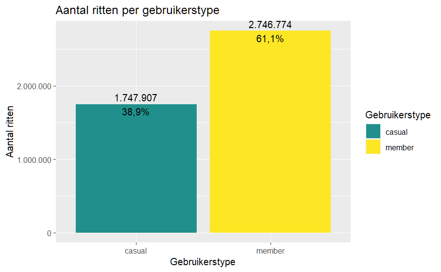

```r
# Stel kleurenpalet in
color_palette2 <- viridis_pal(option = "viridis", begin = 0.5, end = 1)(length(unique(bikes_df_new$member_casual)))

# Aantal ritten onderverdeeld naar Casual en Member
bikes_df_new %>%
  group_by(member_casual) %>%
  summarise(total_rides = n()) %>%
  mutate(percentage = total_rides / sum(total_rides)) %>%
  ggplot(aes(x = member_casual,
             y = total_rides,
             fill = member_casual)) +
  geom_col() +
  geom_text(aes(label = paste0(comma_format(big.mark = ".",
                                            decimal.mark = ",")(total_rides),
                               "\n",
                               percent_format(big.mark = ".",
                                              decimal.mark = ",",
                                              accuracy = 0.1)(percentage))),
            vjust = 0.5) +
  scale_y_continuous(labels = comma_format(big.mark = ".", decimal.mark = ",")) +
  labs(title = "Aantal ritten per gebruikerstype",
       x = "Gebruikerstype",
       y = "Aantal ritten",
       fill = "Gebruikerstype") +
  scale_fill_manual(values = color_palette2)
```

### Aantal ritten per gebruikerstype per maand

In de onderstaande grafiek is duidelijk te zien dat het aantal fietsritten seizoensgebonden is, voor zowel **casuals** als **members**. Dit is niet verwonderlijk, gezien het klimaat in Chicago. Verder is er een klein verschil zichtbaar in het patroon tussen casuals en members. Bij de members blijft het aantal ritten per maand oplopen tot en met augustus. Bij de casuals piekt het in juli en daalt het al vrij snel in augustus.

Daarnaast is de ratio tussen de maanden met de minste ritten en de meeste ritten, veel kleiner bij de members. Namelijk ongeveer (335.230 - augustus) / ( 103.898- december) ≅ 3,2. Terwijl dit bij de casuals meer dan een factor 10 is (311.678 / 29.621).

**NB** Het volledige dataset (5,83 miljoen ritten), veranderd niets aan bovenstaande bevindingen.

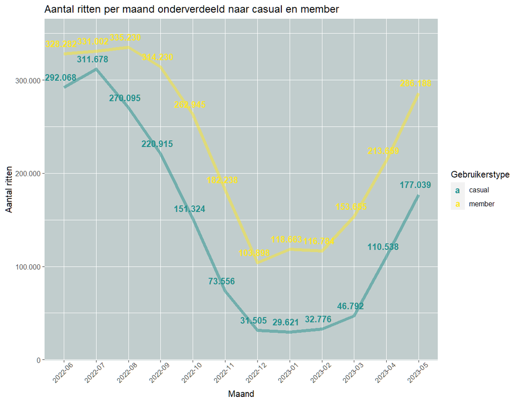

```r
# Aantal ritten per maand onderverdeeld naar casual en member
bikes_df_new %>%
  mutate(start_month = format(as.Date(started_at), "%Y-%m")) %>%
  group_by(member_casual, start_month) %>%
  summarise(total_rides = n()) %>%
  ggplot(aes(x = start_month,
             y = total_rides,
             color = member_casual,
             group = member_casual)) + # afzonderlijke lijn voor iedere member/casual
  geom_line(linewidth = 2,
            show.legend = FALSE,
            alpha = 0.5) + # maakt lijn doorzichtiger
  geom_text(aes(label = paste0(comma_format(big.mark = ".", decimal.mark = ",")(total_rides))), # past scheidingstekens aan naar (1.025,01)
            vjust = -1,
            nudge_x = -0.1,
            nudge_y = -0.2,
            fontface = "bold") +  # vetgedrukte labels
  scale_y_continuous(labels = comma_format(big.mark = ".", decimal.mark = ","),
                     expand = expansion(mult = c(0.1, 0.1))) + # maakt x-as en y-as 10% groter
  labs(title = "Aantal ritten per maand onderverdeeld naar casual en member",
       x = "Maand", y = "Aantal ritten", color = "Gebruikerstype") +
  theme(axis.text.x = element_text(angle = 45, # plaatst x-as label in hoek van 45°
                                   hjust = 0.7, # horizontale uitlijning
                                   vjust = 0.9)) + # verticale uitlijning
  scale_color_manual(values = color_palette2) + # eigen kleurenpalet
  theme(panel.background = element_rect(fill = "#C1CDCD")) # achtergrondkleur grafiek
```

### Aantal ritten per weekdag

Met de originele code kwam er niet het gewenste resultaat uit. Na raadpleging van Bing Chat heb ik de onderstaande code uitgevoerd om vast te stellen welke datum/tijdstippen voor een foutmelding zorgen. Er bleken 17 datum/tijdstippen te zijn, waarbij de rit om 00:00:00 begon, waarmee R in dit geval niet om kon gaan. Om toch een plot weer te geven van het aantal ritten per weekdag, heb ik ervoor gekozen om de weekdag apart op te slaan in een nieuwe kolom, via de mutate functie in het hieropvolgende codeblok.

```r
# Check for incorrectly formatted dates
# Fix incorrectly formatted dates
bikes_df_new_fixed <- bikes_df_new %>%
  mutate(parsed_date = ymd_hms(started_at))

# Check for any remaining incorrectly formatted dates
incorrect_dates <- bikes_df_new_fixed %>%
  filter(is.na(parsed_date))

# View rows with incorrectly formatted dates
incorrect_dates
```

Hieronder staat de code en plot met de alternatieve methode. Daaruit blijkt duidelijk dat members relatief vaak fietsen fietsen gebruikten op werkdagen. En dat bij casuals een relatief groter deel van de fietsritten in het weekend plaatsvond.

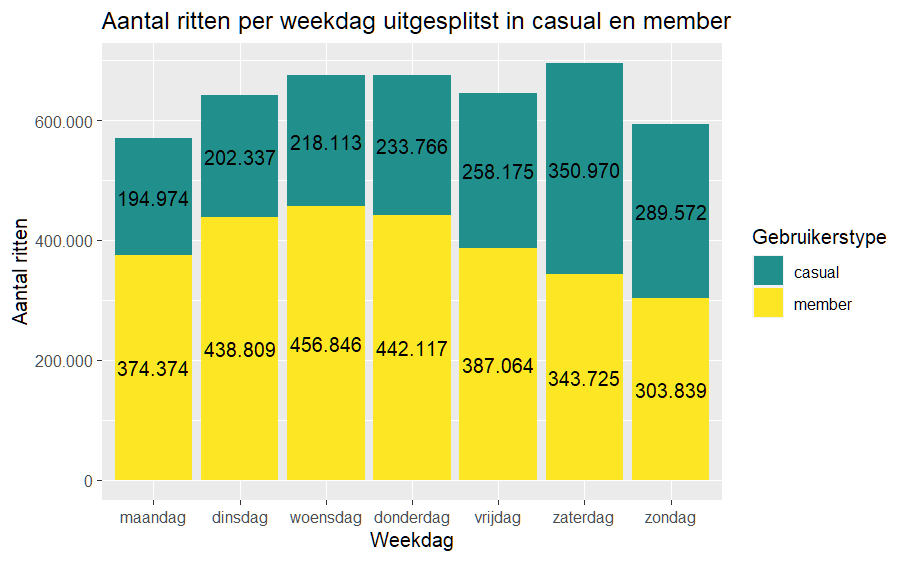

```r
# Aantal ritten per weekdag uitgesplitst naar casual en member
bikes_df_new %>%
  mutate(weekdag = factor(weekday, levels = c("maandag", "dinsdag", "woensdag",
                                              "donderdag", "vrijdag",
                                              "zaterdag", "zondag"))) %>%
  group_by(member_casual, weekdag) %>%
  summarise(aantal_ritten = n()) %>%
  ggplot(aes(x = weekdag,
             y = aantal_ritten,
             fill = member_casual)) +
  geom_col() +
  geom_text(aes(label = paste0(comma_format(big.mark = ".",
                                            decimal.mark = ",")(aantal_ritten))),
            position = position_stack(vjust = 0.5)) +
  scale_y_continuous(labels = comma_format(big.mark = ".",
                                           decimal.mark = ",")) +
  labs(title = "Aantal ritten per weekdag uitgesplitst in casual en member",
       x = "Weekdag",
       y = "Aantal ritten",
       fill = "Gebruikerstype") +
  scale_fill_manual(values = color_palette2)
```

### Aantal ritten per weekdag uitgesplitst naar gebruikerstype en fietssoort

Om deze plot goed te zien, is het verstandig om de onderstaande plot in een nieuw tabblad te openen. Dit kan door met de rechtermuisknop op de plot te klikken en vervolgens de optie *afbeelding openen in nieuw tabblad* te selecteren.

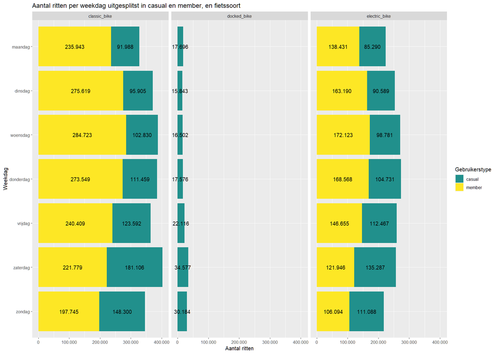

```r
# Aantal ritten per weekdag uitgesplitst naar casual en member en fietstype
bikes_df_new %>%
  mutate(weekdag = factor(weekday, levels = c("zondag", "zaterdag", "vrijdag",
                                              "donderdag", "woensdag",
                                              "dinsdag", "maandag"))) %>%
  group_by(member_casual, weekdag, rideable_type) %>%
  summarise(aantal_ritten = n()) %>%
  ggplot(aes(x = weekdag,
             y = aantal_ritten,
             fill = member_casual)) +
  geom_col() +
  geom_text(aes(label = paste0(comma_format(big.mark = ".",
                                            decimal.mark = ",")(aantal_ritten))),
            position = position_stack(vjust = 0.5)) +
  scale_y_continuous(labels = comma_format(big.mark = ".",
                                           decimal.mark = ",")) +
  labs(title = "Aantal ritten per weekdag uitgesplitst in casual en member, en fietssoort",
       x = "Weekdag",
       y = "Aantal ritten",
       fill = "Gebruikerstype") +
  scale_fill_manual(values = color_palette2) +
  facet_wrap(~rideable_type) +
  coord_flip()
```

### Aantal ritten per weekdag uitgesplitst per maand

De voorgaande twee grafieken geven eenzelfde patroon voor de **members**, namelijk dat dinsdag, woensdag en donderdag de dagen waren waarop de meeste ritten plaatsvonden. En dat in het weekend de minste ritten plaatsvonden. Terwijl dat beeld voor de afzonderlijke maanden juist zeer gevarieerd is, zoals te zien is in onderstaande grafiek.

Het patroon voor de **casuals** is wat eenduidiger, en laat ook enige aanwijzing zien, dat de casuals met name een fiets huren in de weekenden van maanden waarin het weer beter is. Juist in de koude wintermaanden zie je dat er in de weekenden minder ritten plaatsvonden.

Dit vermoeden wordt verder gesterkt als je kijkt naar de ratio tussen de maand met de meeste ritten voor **members** en **casuals.** Dan zie je dat het relatieve verschil (de ratio), veel groter is bij casuals. Dit kan oplopen tot een factor 20, oftewel op de piekdag (zaterdag-juli) vonden 20 keer zoveel ritten plaats dan op de daldag (zaterdag-januari). Voor casuals die een fiets huren, lijken de weersomstandigheden een belangrijkere factor te zijn dan voor de members.

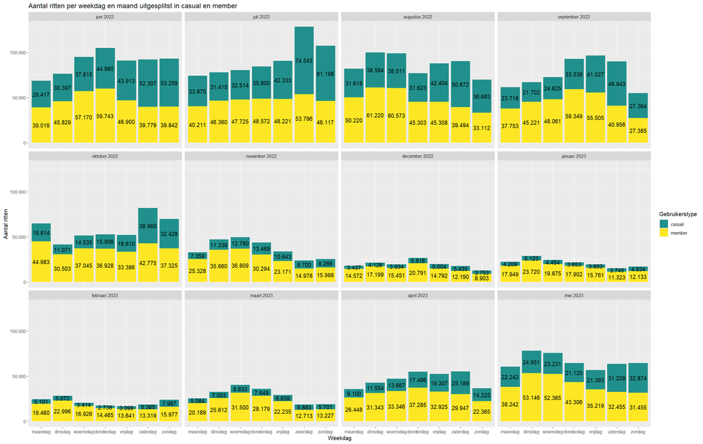

```r
# Aantal ritten per weekdag uitgesplitst naar maand en gebruikerstype
bikes_df_new %>%
  mutate(start_month = factor(format(as.Date(started_at), "%B %Y"),
                              levels = unique(format(as.Date(started_at), "%B %Y")))) %>% #chronologische volgorde
  mutate(weekdag = factor(weekday, levels = c("maandag", "dinsdag", "woensdag",
                                              "donderdag", "vrijdag",
                                              "zaterdag", "zondag"))) %>%
  group_by(member_casual, start_month, weekdag) %>%
  summarise(aantal_ritten = n()) %>%
  ggplot(aes(x = weekdag,
             y = aantal_ritten,
             fill = member_casual)) +
  geom_col() +
  geom_text(aes(label = paste0(comma_format(big.mark = ".",
                                            decimal.mark = ",")(aantal_ritten))),
            position = position_stack(vjust = 0.5)) +  #plaats label in eigen staafsegment
  scale_y_continuous(labels = comma_format(big.mark = ".",
                                           decimal.mark = ",")) +
  labs(title = "Aantal ritten per weekdag en maand uitgesplitst in casual en member",
       x = "Weekdag",
       y = "Aantal ritten",
       fill = "Gebruikerstype") +
  scale_fill_manual(values = color_palette2) +
  facet_wrap(~start_month)
```

### Aantal ritten per uur van de dag

Voor een duidelijker beeld adviseer ik om de grafiek te openen in een nieuw tabblad, door met de rechtermuisknop op de afbeelding te klikken en vervolgens te kiezen voor ‘*Afbeelding openen in nieuw tabblad*’. Hiermee wordt de grafiek in een volledig scherm getoond.

Met de grafiek goed in beeld, is nu duidelijk te zien dat bij de **members** twee pieken in het aantal ritten over de dag te zien zijn. Eén in de ochtend en één rond het begin van de avond. Wellicht dat de pieken verband houden met reizigers die voor hun werk reizen. Bij **casuals** is het patroon met twee pieken niet zichtbaar en blijft het aantal ritten per uur van de dag oplopen tot het begin van de avond.

In de volgende grafiek, kijk ik of dit patroon hetzelfde blijft wanneer ik de gegevens uitsplits naar dag van de week.

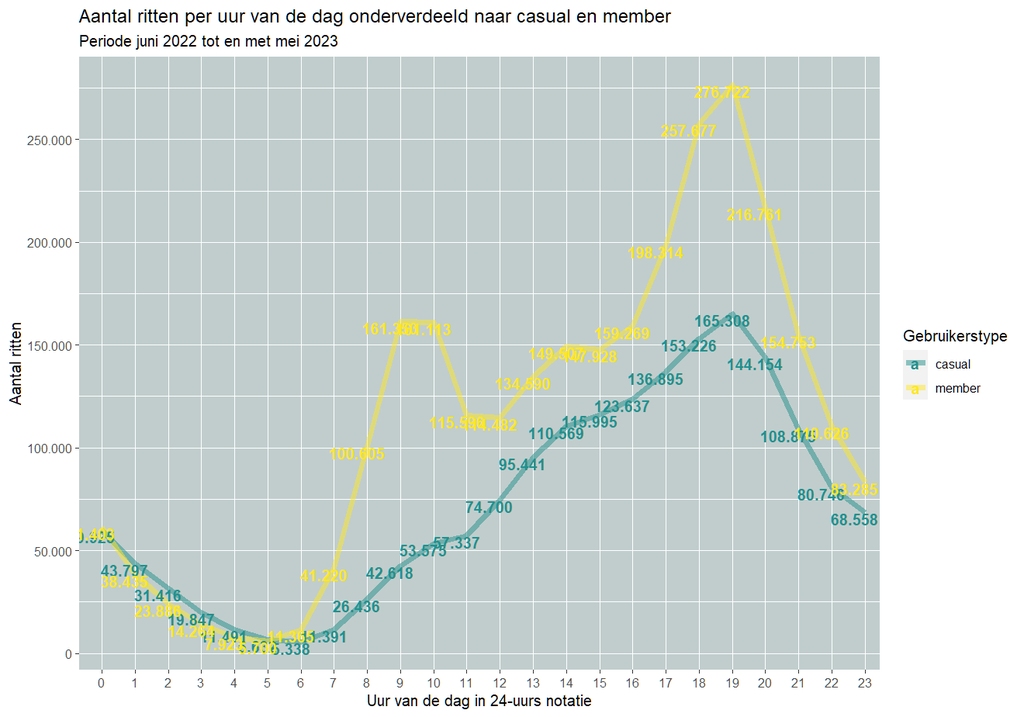

```r
# Aantal ritten per uur van de dag, onderverdeeld naar casual en member
bikes_df_new %>%
  mutate(start_uur = factor(hour(started_at),
                            levels = 0:23)) %>%
  group_by(member_casual, start_uur) %>%
  summarise(aantal_ritten = n()) %>%
  {
    # voegt plot toe
    ggplot(., aes(x = start_uur,
               y = aantal_ritten,
               color = member_casual,
               group = member_casual)) +

      # maakt lijngrafiek
      geom_line(linewidth = 2,
                alpha = 0.5) +

      # voegt labels toe aan de lijngrafiek
      geom_text(aes(label = paste0(comma_format(big.mark = ".",
                                                decimal.mark = ",")(aantal_ritten))),
                vjust = 1,
                nudge_x = -0.3,
                nudge_y = -3,
                fontface = "bold") +

      # Maakt linkerkant van de x-as iets groter
      scale_x_discrete(expand = expansion(mult = c(0.03, 0.02))) +

      # Voegt scheidingstekens toe aan y-as
      scale_y_continuous(breaks = seq(0, max(.$aantal_ritten), by = 50000),
                         labels = comma_format(big.mark = ".",
                                               decimal.mark = ",")) +

      # Voegt titels voor kop, x-as en y-as toe.
      labs(title = "Aantal ritten per uur van de dag onderverdeeld naar casual en member",
      subtitle = "Periode juni 2022 tot en met mei 2023",
           x = "Uur van de dag in 24-uurs notatie",
           y = "Aantal ritten",
           color = "Gebruikerstype") +

      # Voegt eigen kleurenpalet toe
      scale_color_manual(values = color_palette2) +

      # Verander kleur van achtergrond grafiek
      theme(panel.background = element_rect(fill = "#C1CDCD"))
    }
```

```r
NA
```

### Aantal ritten per uur van de dag, uitgesplitst naar weekdag

Ik adviseer weer om de grafiek in een nieuw tabblad te openen. In de vorige grafiek was bij de **members** een patroon zichtbaar, waarbij er twee pieken op een dag waren. Eén in de ochtend en één rond het begin van de avond. In deze grafiek zien we dat dit patroon zich van maandag tot en met vrijdag blijft herhalen. Wat het eerdere vermoeden van werk gerelateerd reizen lijkt te bevestigen. Want, in het weekend vertonen members en **casuals** eenzelfde patroon.

Verder valt op dat ook bij de **casuals**, de verdeling van het aantal ritten op doordeweekse dagen anders is dan in het weekend. Ogenschijnlijk gebruiken casuals de huurfietsen ook om rond kantoortijden te reizen. Aangezien het dubbele piekpatroon ook in lichte mate terugkomt. Al is het aantal werkgerelateerde reizen bij de casuals vermoedelijk een stuk lager. Omdat buiten de piekmomenten het verschil in aantal ritten een stuk kleiner is.

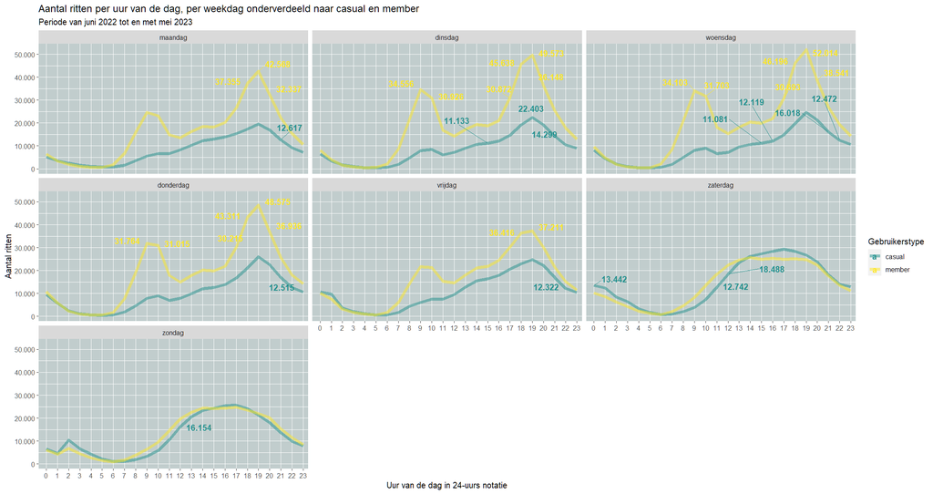

```r
# Aantal ritten per uur van de dag, uitgesplitst naar weekdag

library(ggrepel)

# Limiet om aantal labels verder te reduceren
threshold_casual <- 11000
threshold_member <- 27000

bikes_df_new %>%
  mutate(start_uur = factor(hour(started_at), levels = 0:23)) %>%
  mutate(weekdag = factor(weekday, levels = c("maandag", "dinsdag", "woensdag",
                                              "donderdag", "vrijdag",
                                              "zaterdag", "zondag"))) %>%
  group_by(member_casual, weekdag, start_uur) %>%
  summarise(aantal_ritten = n()) %>%
  {
    ggplot(., aes(x = start_uur,
                  y = aantal_ritten,
                  color = member_casual,
                  group = member_casual)) +
      geom_line(linewidth = 2, alpha = 0.5) +
      geom_text_repel(aes(label = ifelse(member_casual == "member" & aantal_ritten > threshold_member,
                                         paste0(comma_format(big.mark = ".", decimal.mark = ",")(aantal_ritten)),
                                         ifelse(member_casual == "casual" & aantal_ritten > threshold_casual,
                                                paste0(comma_format(big.mark = ".", decimal.mark = ",")(aantal_ritten)),
                                                ""))),
                      box.padding = 0.5, segment.size = 0.2, force = 0.5, min.segment.length = 0.5,
                      max.overlaps = 5, # Adjust the number of allowed overlaps here
                      vjust = 1, fontface = "bold") +
      scale_x_discrete(expand = expansion(mult = c(0.03, 0.02))) +
      scale_y_continuous(breaks = pretty_breaks(n = 6),
                         labels = comma_format(big.mark = ".", decimal.mark = ",")) +
      labs(title = "Aantal ritten per uur van de dag, per weekdag onderverdeeld naar casual en member",
           subtitle = "Periode van juni 2022 tot en met mei 2023",
           x = "Uur van de dag in 24-uurs notatie",
           y = "Aantal ritten",
           color = "Gebruikerstype") +
      scale_color_manual(values = color_palette2) +
      theme(panel.background = element_rect(fill = "#C1CDCD")) +
      facet_wrap(~weekdag)
  }
```

### Aantal ritten per maand en uur van de dag

In deze grafiek kijk ik voor iedere maand naar het aantal ritten dat plaatsvond per uur van de dag. De grafiek laat eenzelfde patroon zien, als de voorgaande twee grafieken. De **members** lijken de fietsen voor een vaste routine te gebruiken, vermoedelijk het werk. Op zich is dat logisch, als je een jaarabonnement hebt. Ook de **casuals** laten eenzelfde gebruik van fietsen zien gedurende het jaar. Het is daarmee de vraag of deze groep gemakkelijk overgehaald kan worden om een jaarabonnement te nemen.

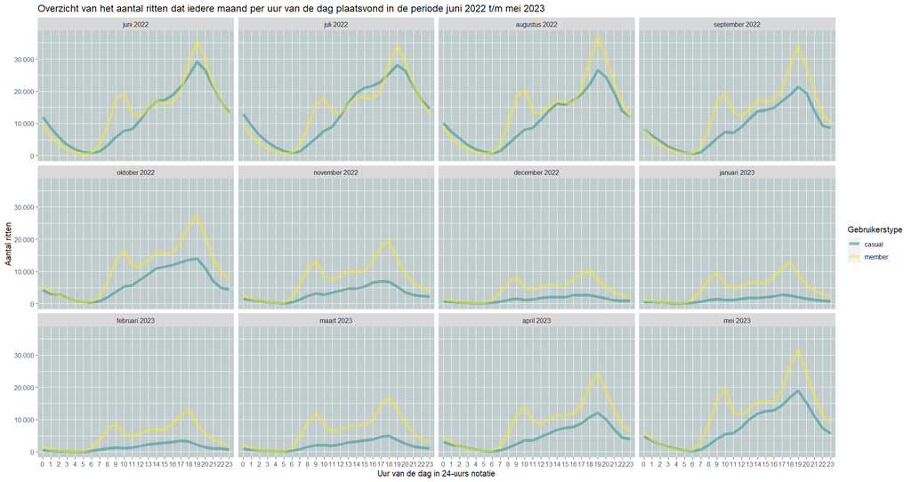

```r
# Aantal ritten per uur van de dag, uitgesplitst naar maand
bikes_df_new %>%
  mutate(start_uur = factor(hour(started_at),
                            levels = 0:23)) %>%
  mutate(start_month = factor(format(as.Date(started_at), "%B %Y"),
                              levels = unique(format(as.Date(started_at), "%B %Y")))) %>% #chronologische volgorde
  group_by(member_casual, start_month, start_uur) %>%
  summarise(aantal_ritten = n()) %>%

  # voegt plot toe
  ggplot(aes(x = start_uur,
                y = aantal_ritten,
                color = member_casual,
                group = member_casual)) +

  # maakt lijngrafiek
  geom_line(linewidth = 2,
            alpha = 0.5) +

  # Voegt scheidingstekens toe aan y-as
  scale_y_continuous(labels = comma_format(big.mark = ".",
                                           decimal.mark = ",")) +

  # Voegt titels voor kop, x-as en y-as toe.
  labs(title = "Overzicht van het aantal ritten dat iedere maand per uur van de dag plaatsvond in de periode juni 2022 t/m mei 2023",
       x = "Uur van de dag in 24-uurs notatie",
       y = "Aantal ritten",
       color = "Gebruikerstype") +

  # Voegt eigen kleurenpalet toe
  scale_color_manual(values = color_palette2) +

  # Verander kleur van achtergrond grafiek
  theme(panel.background = element_rect(fill = "#C1CDCD")) +

  # Facet
  facet_wrap(~start_month)
```

### Aantal ritten per fietssoort onderverdeeld naar gebruikerstype

Uit onderstaande plot blijkt dat casuals vaker een elektrische fiets gebruiken dan members. Overigens valt het op dat met het complete dataset (5,83 miljoen ritten), de verhoudingen er heel anders uitzien:

- Casuals: 56,1% elektrische fietsen
- Members 50,8% elektrische fietsen

Schijnbaar worden de station_id’s minder vaak vastgelegd bij het gebruik van elektrische fietsen.

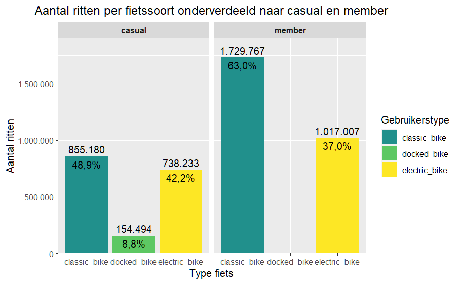

```r
# Stel kleurenpalet in
color_palette <- viridis_pal(option = "viridis", begin = 0.5, end = 1)(length(unique(bikes_df_new$rideable_type)))

# Aantal ritten per fietssoort onderverdeeld naar casual en member
bikes_df_new %>%
  group_by(member_casual, rideable_type) %>%
  summarise(total_rides = n()) %>%
  mutate(percentage = total_rides / sum(total_rides)) %>%
  ggplot(aes(x = rideable_type,
             y = total_rides,
             fill = rideable_type)) +
  geom_col() +
  geom_text(aes(label = paste0(comma_format(big.mark = ".", decimal.mark = ",")(total_rides),
                               "\n", # enter (nieuwe regel)
                               percent_format(big.mark = ".",
                                              decimal.mark = ",",
                                              accuracy = 0.1)(percentage))), # 1 decimaal
            vjust = 0.5) +
  scale_y_continuous(labels = comma_format(big.mark = ".", decimal.mark = ","),
                     expand = expansion(mult = c(0, 0.1))) +  # maakt bovenkant y-as 10% groter
  labs(title = "Aantal ritten per fietssoort onderverdeeld naar casual en member",
       x = "Type fiets" ,
       y = "Aantal ritten",
       fill = "Gebruikerstype") +
  theme(plot.title = element_text(hjust = 0.5)) +
  facet_wrap(~member_casual) +
  theme(strip.text.x = element_text(face = "bold")) + #vetgedrukte facets
  scale_fill_manual(values = color_palette)  # gebruik eigen kleurenpalet
```

### Boxplot met de verdeling (distribution) van ritduur

Om de verdeling van de ritduur per weekdag weer te geven gebruik ik boxplots. Ritten korter dan 0 minunten en langer dan 65 minuten zijn weggefilterd, omdat dit duidelijke outliers zijn. Aangezien er best wat uitschieters naar boven zijn, gebruik ik in de hier opvolgende grafieken de mediaan in plaats van het gemiddelde, om te bepalen wat de gebruikelijke ritduur is voor casuals en members. Omdat het gemiddelde door de vele uitschieters een vertekend beeld geeft.

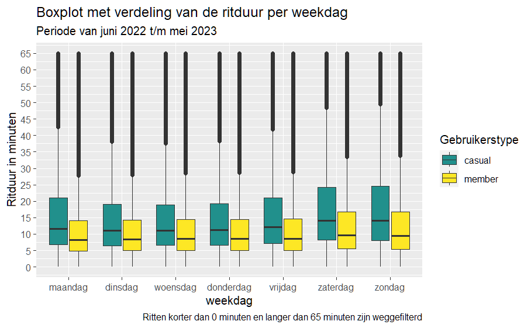

```r
# Boxplot van de duur van fietsritten per weekdag
bikes_df_new %>%
  dplyr::filter(ride_duration < 65 & ride_duration > 0) %>%
  mutate(weekdag = factor(weekday, levels = c("maandag", "dinsdag", "woensdag",
                                              "donderdag", "vrijdag",
                                              "zaterdag", "zondag"))) %>%
  group_by(member_casual, weekdag) %>%
  ggplot(aes(x = weekdag,
             y = ride_duration,
             fill = member_casual)) +
  geom_boxplot() +
  scale_y_continuous(breaks = seq(0, 65, by = 5)) +
  scale_fill_manual(values = color_palette2) +
  labs(title = "Boxplot met verdeling van de ritduur per weekdag",
       subtitle = "Periode van juni 2022 t/m mei 2023",
       caption = "Ritten korter dan 0 minuten en langer dan 65 minuten zijn weggefilterd",
       y = "Ritduur in minuten",
       fill = "Gebruikerstype")
```

### Mediane ritduur per gebruikerstype

In de periode juni 2022 t/m mei 2023, was de mediane ritduur van casuals met ongeveer 13,1 minuten per fietsrit ongeveer 50% langer dan de members met hun mediane ritduur van 8,8 minuten per fietsrit.

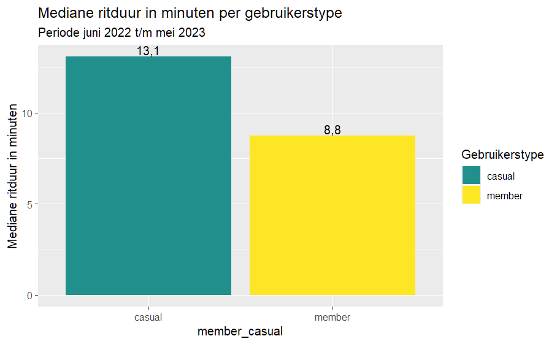

```r
# Mediane ritduur per gebruikerstype
bikes_df_new %>%
  dplyr::filter(ride_duration > 0) %>%
  mutate(ride_duration = as.numeric(ride_duration)) %>%
  group_by(member_casual) %>%
  summarise(med_ritduur = median(ride_duration)) %>%
  ggplot(aes(x = member_casual,
             y = med_ritduur,
             fill = member_casual)) +
  geom_col() +
  geom_text(aes(label = paste0(comma_format(big.mark = ".",
                                            decimal.mark = ",")(med_ritduur))),
            vjust = -0.2) +
  labs(title = "Mediane ritduur in minuten per gebruikerstype",
       subtitle = "Periode juni 2022 t/m mei 2023",
       y = "Mediane ritduur in minuten",
       fill = "Gebruikerstype") +
  scale_fill_manual(values = color_palette2)
```

### Mediane ritduur per type fiets en gebruikerstype

Om wat verder in te gaan op de verschillen in ritduur tussen casuals en members, kijk ik hier hoe de mediane ritduur in minuten varieert, afhankelijk van het type fiets. Uit deze plot blijkt dat met name de docked bikes langer zijn gebruikt. Het verschil in ritduur bij elektrische fietsen is het kleinste.

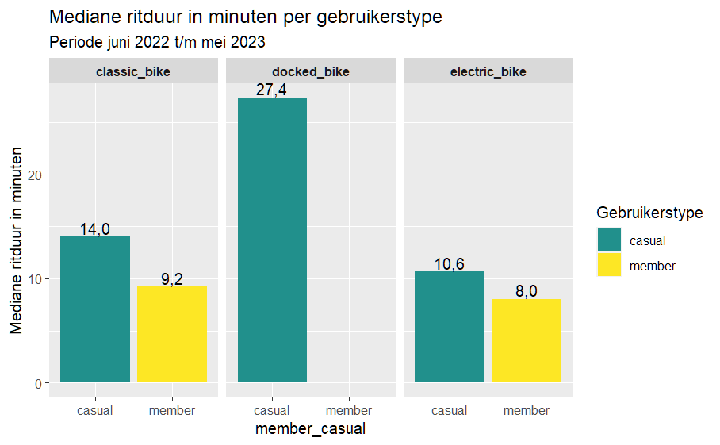

```r
# Mediane ritduur per gebruikerstype en fietstype
bikes_df_new %>%
  dplyr::filter(ride_duration > 0) %>%
  mutate(ride_duration = as.numeric(ride_duration)) %>%
  group_by(member_casual, rideable_type) %>%
  summarise(med_ritduur = median(ride_duration)) %>%
  ggplot(aes(x = member_casual,
             y = med_ritduur,
             fill = member_casual)) +
  geom_col() +
  geom_text(aes(label = paste0(comma_format(big.mark = ".",
                                            decimal.mark = ",")(med_ritduur))),
            vjust = -0.2) +
  labs(title = "Mediane ritduur in minuten per gebruikerstype",
       subtitle = "Periode juni 2022 t/m mei 2023",
       y = "Mediane ritduur in minuten",
       fill = "Gebruikerstype") +
  scale_fill_manual(values = color_palette2) +  #eigen kleurenpalet
  facet_wrap(~rideable_type) +
  theme(strip.text.x = element_text(face = "bold"))  #vetgedrukte facets
```

### Mediane ritduur per weekdag

In onderstaande grafiek zien we weer terug dat binnen de groep casuals, er meer variatie is in de mediane ritduur gedurende de week. Dit zagen we voor casuals eerder ook al terug in het aantal ritten per weekdag en maand van het jaar.

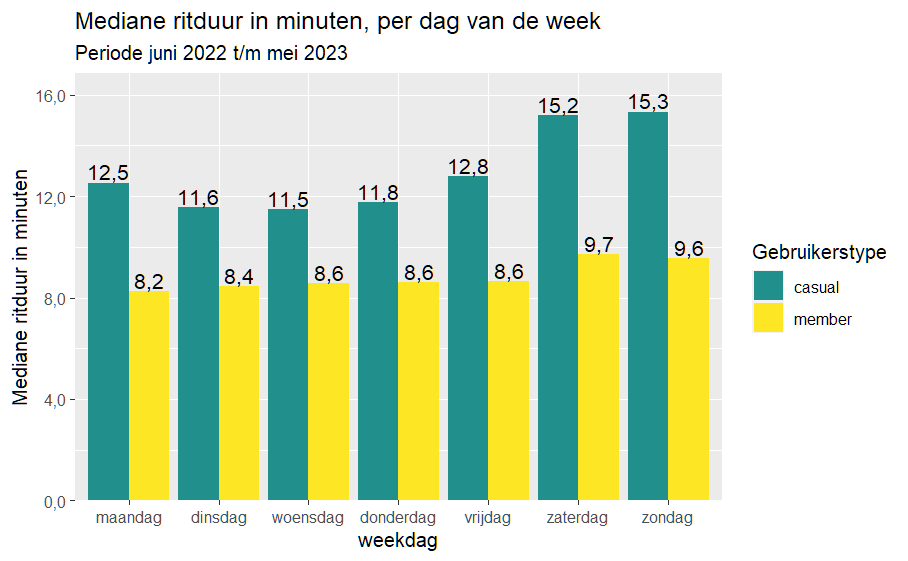

```r
# Mediane ritduur per weekdag
bikes_df_new %>%
  dplyr::filter(ride_duration > 0) %>%
  mutate(ride_duration = as.numeric(ride_duration)) %>%
  mutate(weekdag = factor(weekday, levels = c("maandag", "dinsdag", "woensdag",
                                              "donderdag", "vrijdag",
                                              "zaterdag", "zondag"))) %>%
  group_by(member_casual, weekdag) %>%
  summarise(med_ritduur = median(ride_duration)) %>%
  ggplot(aes(x = weekdag,
             y = med_ritduur,
             fill = member_casual)) +
  geom_col(position = "dodge") +
  geom_text(aes(label = comma_format(accuracy = 0.1, big.mark = ".", decimal.mark = ",")(med_ritduur)),
            position = position_dodge(width = 0.9),
            hjust = 0.5,
            vjust = -0.2,
            size = 4) +  # Adjust size to your preference
  labs(title = "Mediane ritduur in minuten, per dag van de week",
       subtitle = "Periode juni 2022 t/m mei 2023",
       y = "Mediane ritduur in minuten",
       fill = "Gebruikerstype") +
  scale_fill_manual(values = color_palette2) +
  scale_y_continuous(labels = comma_format(accuracy = 0.1,
                                           big.mark = ".",
                                           decimal.mark = ","),
                     expand = expansion(mult = c(0, 0.1))) + # maakt rechterkant x-as 10% groter
  theme(strip.text.x = element_text(face = "bold"))
```

### Mediane ritduur per weekdag, uitgesplitst per maand

Ik adviseer om deze grafiek in een nieuw tabblad te bekijken, zodat die duidelijk te bekijken is. Dan is te zien dat deze grafiek het verloop van de mediane ritduur per dag van de week over de maanden van het jaar weergeeft. Ter vergelijking, heb ik de mediaan van de **casuals** over de afgelopen 12 maanden, als donkergroene stippellijn toegevoegd. De jaarmedian van de **members** is te herkennen aan de rode stippellijn. Daarin is nogmaals te zien dat de seizoensvariatie binnen de groep casuals groter is dan bij de members. Bij de members ligt de mediane ritduur per weekdag juist het hele jaar rond de algehele mediane ritduur van de afgelopen 12 maanden.

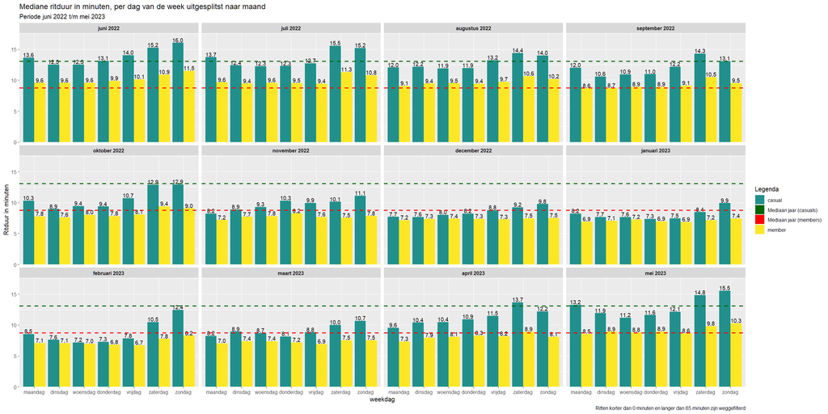

```r
# Bereken de mediane ritduur voor casuals en members per weekdag over het gehele jaar     V
medians <- bikes_df_new %>%
  dplyr::filter(ride_duration > 0) %>%
  mutate(ride_duration = as.numeric(ride_duration)) %>%
  group_by(member_casual) %>%
  summarise(med_ritduur_jaar = median(ride_duration))

# Maak een nieuwe data frame met de legenda informatie
legenda_data <- data.frame(member_casual = c("member", "casual", "Mediaan jaar (members)", "Mediaan jaar (casuals)"),
                           fill = c(color_palette2[1], "darkgreen", "red", color_palette2[2]),
                           linetype = c(NA, NA, "dashed", "dashed"))

bikes_df_new %>%
  dplyr::filter(ride_duration > 0 & ride_duration < 65) %>%
  mutate(start_month = factor(format(as.Date(started_at), "%B %Y"),
                              levels = unique(format(as.Date(started_at), "%B %Y")))) %>% #chronologische volgorde
  mutate(ride_duration = as.numeric(ride_duration)) %>%
  mutate(weekdag = factor(weekday, levels = c("maandag", "dinsdag", "woensdag",
                                              "donderdag", "vrijdag",
                                              "zaterdag", "zondag"))) %>%
  group_by(member_casual, start_month, weekdag) %>%
  summarise(med_ritduur = median(ride_duration)) %>%
  ggplot(aes(x = weekdag,
             y = med_ritduur,
             fill = member_casual)) +
  geom_col(position = "dodge") +
  geom_text(aes(label = comma_format(accuracy = 0.1, big.mark = ".", decimal.mark = ",")(med_ritduur)),
            position = position_dodge(width = 0.9),
            hjust = 0.5,
            vjust = -0.2,
            size = 3.5) +  # Adjust size to your preference
  labs(title = "Mediane ritduur in minuten, per dag van de week uitgesplitst naar maand",
       subtitle = "Periode juni 2022 t/m mei 2023",
       caption = "Ritten korter dan 0 minuten en langer dan 65 minuten zijn weggefilterd",
       y = "Ritduur in minuten") +
  scale_fill_manual(values=legenda_data$fill, name="Legenda") +
  scale_linetype_manual(values=legenda_data$linetype, name="Legenda") +
  scale_y_continuous(labels=comma_format(accuracy=1,
                                         big.mark=".",
                                         decimal.mark=","),
                     expand=expansion(mult=c(0,0.1))) + # maakt bovenkant y-as 10% groter) +
  theme(strip.text.x=element_text(face="bold")) +

  #Voegt de geom_hline en geom_blank functies toe
  geom_hline(data=medians[medians$member_casual=="member",],
             aes(yintercept=med_ritduur_jaar),
             linetype="dashed",
             linewidth = 0.8,
             color="red") +
  geom_hline(data=medians[medians$member_casual=="casual",],
             aes(yintercept=med_ritduur_jaar),
             linetype="dashed",
             linewidth = 1,
             color="darkgreen") +
  geom_blank(data=legenda_data, aes(fill=member_casual, linetype=member_casual), inherit.aes = FALSE) +
  facet_wrap(~start_month)
```

### Mediane ritduur per uur van de dag

In deze grafiek is duidelijk waarneembaar dat de mediane ritduur bij de **casuals** anders verloopt over de uren van de dag dan bij de **members**. Dit patroon is terug te zien in alle maanden van het jaar, dit laat ik hier niet zien aan de hand van een aparte grafiek, omdat dit geen nieuwe inzichten verschaft en ik er geen nieuwe R technieken mee leer.

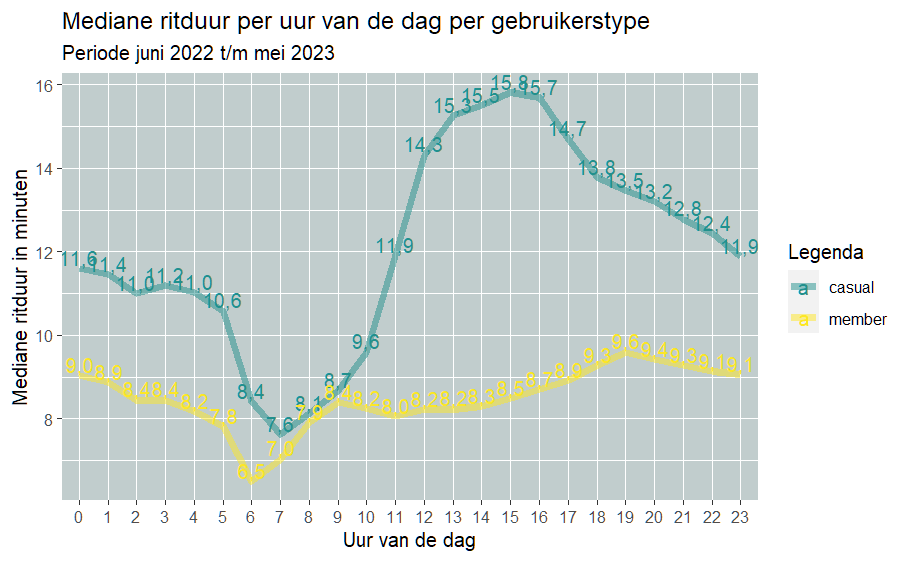

```r
# Mediane ritduur per uur van de dag
bikes_df_new %>%
  mutate(start_uur = factor(hour(started_at),
                            levels = 0:23)) %>%
  group_by(member_casual, start_uur) %>%
  summarise(med_ritduur = median(as.numeric(ride_duration))) %>%
  ggplot(aes(x = start_uur,
         y = med_ritduur,
         color = member_casual,
         group = member_casual)) +
  geom_line(linewidth = 2, alpha = 0.5) +
  geom_text(aes(label = paste0(comma_format(accuracy = 0.1,
                                            big.mark = ".",
                                            decimal.mark = ",")(med_ritduur))),
            vjust = -0.2) +
  labs(title = "Mediane ritduur per uur van de dag per gebruikerstype",
       subtitle = "Periode juni 2022 t/m mei 2023",
       x = "Uur van de dag",
       y = "Mediane ritduur in minuten") +
  scale_color_manual(values = color_palette2, name="Legenda") + # eigen kleurenpalet
  theme(panel.background = element_rect(fill = "#C1CDCD")) # achtergrondkleur grafiek
```

### Populairste startstations

Onderstaande tabel toont de populairste 10 start_station_id’s per gebruikerstype (member of casual). Hieruit blijkt dat **casuals** andere voorkeuren hebben dan **members**. Dit ga ik nader onderzoeken in de volgende paragraaf aan de hand van een aantal map plots (plattegrond met visualisatie).

```r
# Populairste start stations per gebruikerstype
bikes_df_new %>%
  group_by(member_casual, start_station_id) %>%
  summarise(nr_rides = n_distinct(ride_id),
            # neemt de eerste station_name over van elke groep
            start_station_name = first(start_station_name)) %>%
  slice_max(nr_rides, n = 10) %>%
  arrange(-nr_rides)
```

| member_casual | start_station_id | nr_rides | start_station_name |
| --- | --- | --- | --- |
| casual | 13022 | 52624 | Streeter Dr & Grand Ave |
| casual | 13300 | 29958 | DuSable Lake Shore Dr & Monroe St |
| member | KA1503000043 | 23602 | Kingsbury St & Kinzie St |
| casual | 13042 | 23181 | Michigan Ave & Oak St |
| casual | 13008 | 23035 | Millennium Park |
| member | TA1307000039 | 21561 | Clark St & Elm St |
| casual | LF-005 | 21484 | DuSable Lake Shore Dr & North Blvd |
| member | WL-012 | 20890 | Clinton St & Washington Blvd |
| member | TA1308000050 | 19935 | Wells St & Concord Ln |
| member | 13332 | 19813 | Loomis St & Lexington St |

[output cut: 10 more lines]

### Populairste startstations op kaart

Hieronder heb ik een interactieve kaart gemaakt die de 20 startstations toont met het hoogste aantal ritten. De 20 startstations zijn verdeeld in casuals (blauw) en members (rood), met 10 stations voor elk. Deze kaart laat dus de 10 meest populaire startstations zien voor zowel casuals als members. Omdat de kaart interactief is, kun je inzoomen en op de cirkels klikken voor meer informatie.

Een van de dingen die opvalt, is dat populairste startstations voor **casuals** vaker in de buurt van recreatiegebieden te vinden zijn. Terwijl de populairste startstations voor **members** vaker in de buurt van OV-knooppunten, ‘downtown’ en de universiteit van Chicago te vinden zijn.

In de volgende interactieve kaarten probeer ik meer inzicht in deze verschillen te krijgen.

```r
# 4.5.2 Plot van populairste start stations per gebruikerstype
pop_start_stations <- bikes_df_new %>%
  group_by(member_casual, start_station_id) %>%
  summarise(nr_rides = n_distinct(ride_id),
            # neemt de eerste station_name over van elke groep
            start_station_name = first(start_station_name),
            start_lat = first(start_lat),
            start_lng = first(start_lng)) %>%
  slice_max(nr_rides, n = 10) %>%
  arrange(-nr_rides) %>%
  mutate(nr_rides = scales::comma_format(big.mark = ".")(nr_rides))

library(OpenStreetMap)
library(openlayers)
library(leaflet)
library(leaflet.providers)
library(RColorBrewer)

# Plot de populairste start_station_id's op een kaart
# Maak een kaart van Chicago
chicago_map <- leaflet()

# Verwijder bestaande legenda's van de kaart
chicago_map <- clearControls(chicago_map)

# Voeg markers toe aan de kaart
chicago_map <- chicago_map %>%
  addProviderTiles("OpenStreetMap") %>%
  addCircleMarkers(data = pop_start_stations,
                   lat = ~start_lat,
                   lng = ~start_lng,
                   popup = ~paste0("Station: ", start_station_name,
                                   "<br> Aantal ritten: ", nr_rides),
                   group = ~member_casual,
                   color = ~ifelse(member_casual == "member", "red", "blue")) %>%
  addLegend(position = "bottomright",
            colors = c("red", "blue"),
            labels = c("Member", "Casual"),
            title = "Legenda")

# Plot de kaart
chicago_map
```

[interactive chart not shown]

### Bubble Map met aantal ritten per startstation

Alvorens ik de Bubble Map kan maken met de juiste specificaties, moet ik een aantal dingen instellen. Dit is terug te zien in de onderstaande code. Ik maak een nieuw data frame aan, met daarin alle combinaties van member of casual en start_station_id. Bij elk van deze combinaties zoek ik hoe vaak deze voorkomen en wat de coördinaten zijn. Ondanks dat ik in een eerder hoofdstuk heb beschreven hoe ik verkeerde coördinaten heb gecorrigeerd, kan het zijn dan mijn methode niet waterdicht is. Waardoor de `first(start_lat)` verb in theorie verkeerde coördinaten over kan nemen. Ik heb daarom van een aantal stations de naam in Google Maps ingevoerd en de locaties kwamen overeen met de kaart.

Verder beperk ik de maximale radius van de cirkels en gebruik ik een aangepaste schaal door een eigen gemaakte functie te maken.

Tot slot, om de Bubble Map te veruidelijken, gebruik ik een omgekeerd regenboogspectrum (`rev(brewer.pal())`), waarbij de kleur afhankelijk is van het aantal ritten.

```r
# Bubblemap met aantal ritten per start_station
start_stations <- bikes_df_new %>%
  group_by(member_casual, start_station_id) %>%
  summarise(nr_rides = n_distinct(ride_id),
            # neemt de eerste coördinaten over van elke groep
            start_lat = first(start_lat),
            start_lng = first(start_lng)) %>%
  arrange(-nr_rides)

# Bepaal de maximale grootte van de cirkels
max_radius <- 50

# Maak een functie om de grootte van de cirkels te bepalen op basis van het aantal ritten
radius_func <- function(nr_rides) {
  scales::rescale(nr_rides, to = c(1, max_radius))
}


# Kleurenpalet Bubble Map
color_palette_heat <- colorBin(palette = rev(brewer.pal(7, "Spectral")),
                               domain = start_stations$nr_rides)
```

Met deze specificaties kan ik hieronder een Bubble Map maken. De onderstaande kaart toont de verdeling van alle Divvy bike stations waar een rit is gestart door zowel casuals als members, in de periode juni 2022 t/m mei 2023. De radius en de kleur van de cirkels zijn afhankelijk van het aantal ritten. Hierdoor is het gemakkelijk om drukbezochte stations te identificeren. Zo kunnen we zien dat de stations met het hoogste aantal ritten geclustered zijn rond de pier en het zakencentrum met de vele hoge torens. In de volgende twee plots kijk ik naar de verschillen tussen **casuals** en **members**.

```r
# Bubble Map met aantal ritten per start_station
leaflet(data = start_stations) %>%
  addTiles() %>%
  addCircleMarkers(
    lat = ~start_lat,
    lng = ~start_lng,
    radius = ~radius_func(nr_rides),   # stelt radius in
    fillColor = ~color_palette_heat(nr_rides),
    stroke = FALSE,  # geen rand om cirkel
    fillOpacity = 0.5) %>% # bepaalt doorzichtigheid, 1 = niet doorzichtig
  addLegend(
    position = "bottomright",
    pal = color_palette_heat,
    values = ~nr_rides,
    title = "Aantal ritten",
    opacity = 0.5)
```

[interactive chart not shown]

#### Bubble Map casuals

De onderstaande kaart toont de verdeling van alle Divvy bike stations waar een rit is gestart door **casuals** in de periode juni 2022 t/m mei 2023. Het is goed om ook gelijk naar de kaart van de **members** te kijken, dier verder naaronder is weergegeven. Dan is goed te zien dat bij de casuals de clustering rond enkele stations groter is, en dat er bij de members een gelijkmatigere spreiding is dan bij de casuals. Het aantal ritten rond het zakelijke district ligt lager bij de casuals.

```r
# Bubble Map op kaart met aantal ritten per start_station voor casuals

start_stations %>%
  dplyr::filter(member_casual == "casual") %>%
  leaflet() %>%
  addTiles() %>%
  addCircleMarkers(
    lat = ~start_lat,
    lng = ~start_lng,
    radius = ~radius_func(nr_rides),
    fillColor = ~color_palette_heat(nr_rides),
    stroke = FALSE,
    fillOpacity = 0.5) %>%
  addLegend(
    position = "bottomright",
    pal = color_palette_heat,
    values = ~nr_rides,
    title = "Aantal ritten door casuals",
    opacity = 0.5)
```

[interactive chart not shown]

#### Bubble Map members

Bij de **members** is de spreiding veel gelijkmatiger, met meer nadruk rond het zakendistrict. Er zijn geen stations die er heel sterk bovenuit springen zoals bij de **casuals**. Dat past op zich goed bij het scenario waarbij members de fiets voor ‘last mile’ woon-werkverkeer gebruiken. Aangezien mensen op verschillende plekken werken, is het logisch dat ze verschillende startpunten hebben.

```r
# Bubble Map op kaart met aantal ritten per start_station voor members

start_stations %>%
  dplyr::filter(member_casual == "member") %>%
  leaflet() %>%
  addTiles() %>%
  addCircleMarkers(
    lat = ~start_lat,
    lng = ~start_lng,
    radius = ~radius_func(nr_rides),
    fillColor = ~color_palette_heat(nr_rides),
    stroke = FALSE,
    fillOpacity = 0.5) %>%
  addLegend(
    position = "bottomright",
    pal = color_palette_heat,
    values = ~nr_rides,
    title = "Aantal ritten door members",
    opacity = 0.5)
```

[interactive chart not shown]

#### Bubble Maps met mediane ritduur en aantal ritten

Interessant, is om ook even te kijken wat de mediane ritduur is bij het populairste station. Die blijkt dan bijna 25 minuten te zijn. Tegenover ongeveer 13 minuten voor de groep casuals in het algemeen.

```r
# Median ride duration casuals at most popular start station
bikes_df_new %>%
  dplyr::filter(start_station_id == "13022" & member_casual == "casual") %>%
  summarise(median_ride_time = median(ride_duration))
```

| median_ride_time |
| --- |
| 24.85 mins |

Hoe verhoudt deze tijd zich tot andere stations met minimaal 1.000 ritten?

```r
# Start stations with longest median ride durations for casuals
bikes_df_new %>%
  dplyr::filter(member_casual == "casual") %>%
  group_by(start_station_id) %>%
  dplyr::filter(n_distinct(ride_id) > 1000) %>%
  summarise(median_ride_time = median(ride_duration),
            nr_rides = n_distinct(ride_id)) %>%
  slice_max(median_ride_time, n = 20)
```

| start_station_id | median_ride_time | nr_rides |
| --- | --- | --- |
| KA1503000074 | 40.63333 mins | 2621 |
| KA1503000004 | 34.43333 mins | 1095 |
| TA1307000048 | 30.01667 mins | 3782 |
| 13124 | 26.23333 mins | 3719 |
| 15576 | 25.88333 mins | 5473 |
| 13008 | 25.06667 mins | 23035 |
| 15545 | 24.93333 mins | 4247 |
| 639 | 24.89167 mins | 3896 |
| 13022 | 24.85000 mins | 52624 |
| 13042 | 24.65000 mins | 23181 |

[output cut: 10 more lines]

Het start_station (KA1503000074) met de langste mediane ritduur blijkt bij het Museum of Science and Industry te liggen. Ook zien we een aantal populaire stations terug bij de top 20 start_stations met de langste mediane ritduur.

Op de volgende twee kaarten toon ik de mediane ritduur en het aantal ritten per station. De mediane ritduur wordt weerspiegeld door de omvang van de cirkel en het aantal ritten is terug te zien aan de hand van de kleur van de cirkel.

Echter om deze kaarten te maken heb ik wat omvangrijkere code nodig dan gebruikelijk. Mede omdat het leaflet.legend pakket niet up-to-date is. Daardoor heb ik met behulp van Bing Chat zelf een functie gemaakt die een tweede legenda item (de mediane ritduur) aan de kaart toevoegt. Verder ben ik ook niet bekend met Javascript en CSS, maar daar kon Bing Chat gelukkig mee helpen. Dus voor wat betreft het tweede legenda-item, gaan alle credits in dit geval naar Bing Chat en de mensen van wie de bot geleerd heeft :)

```r
# Tabel met ritduur per start_station                                       V
start_stations_ritduur <- bikes_df_new %>%
  group_by(member_casual, start_station_id) %>%
  dplyr::filter(n_distinct(ride_id) > 1000) %>%  # alleen stations met meer dan 1000 ritten
  summarise(med_ritduur = median(ride_duration),
            nr_rides = n_distinct(ride_id),
            # neemt de eerste coördinaten over van elke groep
            start_station_name = first(start_station_name),
            start_lat = first(start_lat),
            start_lng = first(start_lng)) %>%
  mutate(as.numeric(med_ritduur)) %>%
  arrange(-med_ritduur)

start_stations_ritduur$med_ritduur <- as.numeric(start_stations_ritduur$med_ritduur)

# Bepaal de maximale grootte van de cirkels
max_radius_ritduur <- 50

# Maak een functie om de grootte van de cirkels te bepalen op basis van het aantal ritten
radius_func_ritduur <- function(med_ritduur) {
  scales::rescale(med_ritduur, to = c(1, max_radius))
}

# Kleurenpalet Bubble Map
color_palette_ritduur <- colorBin(palette = rev(brewer.pal(5, "Spectral")),
                               domain = start_stations_ritduur$nr_rides)

# Define the values and labels for the legend
legend_values <- c(10, 20, 30, 40)
legend_labels <- c(">10 minuten", ">20 minuten", ">30 minuten", ">40 minuten")

# Create a function to generate the HTML content for the legend
legendContent <- function(legend_values, legend_labels) {
  max_value <- max(legend_values)
  svg_width <- max_value * 2 + 10
  content <- "<div style='background-color: rgba(255, 255, 255, 0.7); padding: 5px; border-radius: 5px;'>"
  content <- paste0(content, "<h4>Mediane ritduur</h4>")
  for (i in seq_along(legend_values)) {
    svg_height <- legend_values[i] * 2 + 10
    content <- paste0(content, "<div><svg height='",
                      svg_height, "' width='",
                      svg_width, "'><circle cx='",
                      max_value + 5, "' cy='",
                      legend_values[i] + 5, "' r='",
                      legend_values[i], "' fill='#3388ff' fill-opacity='0.5' stroke='false'></circle></svg> ",
                      legend_labels[i], "</div>")
  }
  content <- paste0(content, "</div>")
  return(content)
}
```

Onder deze code, toon ik twee kaarten met de mediane ritduur en het aantal ritten voor zowel casuals en members.

#### Bubble Map mediane ritduur en aantal ritten voor casuals

Op onderstaande kaart kunnen we zien dat de mediane ritduur hoger ligt in de buurt van de recreatiegebieden aan waterkant van Chicago.

```r
# Bubble Map mediane ritduur en aantal ritten - Casuals
start_stations_ritduur %>%
  dplyr::filter(member_casual == "casual") %>%
  leaflet() %>%
  addTiles() %>%
  addCircleMarkers(
    lat = ~start_lat,
    lng = ~start_lng,
    radius = ~radius_func_ritduur(med_ritduur),
    fillColor = ~color_palette_ritduur(nr_rides),
    stroke = FALSE,
    fillOpacity = 0.5) %>%
  addLegend(
    position = "bottomright",
    pal = color_palette_ritduur,
    values = ~nr_rides,
    title = "Aantal ritten door casuals",
    opacity = 0.5) %>%
  addControl(
    html = legendContent(legend_values, legend_labels),
    position = "bottomright"
  )
```

[interactive chart not shown]

#### Bubble Map mediane ritduur en aantal ritten voor members

Ook bij de members zien we op onderstaande kaart, dat de mediane ritduur over het algemeen hoger ligt nabij dezelfde recreatiegebieden. Daarnaast valt op, dat de mediane ritduur bij het Museum of Science & Industry bij members een stuk lager ligt dan bij casuals. Bij de casuals was dit juist het startstation met de langste mediane ritduur (gefilterd op aantal ritten > 1000).

```r
# Bubble Map mediane ritduur en aantal ritten - Members
start_stations_ritduur %>%
  dplyr::filter(member_casual == "member") %>%
  leaflet() %>%
  addTiles() %>%
  addCircleMarkers(
    lat = ~start_lat,
    lng = ~start_lng,
    radius = ~radius_func_ritduur(med_ritduur),
    fillColor = ~color_palette_ritduur(nr_rides),
    stroke = FALSE,
    fillOpacity = 0.5) %>%
  addLegend(
    position = "bottomright",
    pal = color_palette_ritduur,
    values = ~nr_rides,
    title = "Aantal ritten door members",
    opacity = 0.5) %>%
  addControl(
    html = legendContent(legend_values, legend_labels),
    position = "bottomright"
  )
```

[interactive chart not shown]

# Samenvatting

Voordat ik met aanbevelingen begin, is het denk ik goed om weer even het doel van deze analyse helder te hebben. De onderzoeksvraag luidt:

*How do annual members and casual riders use Cyclistic bikes differently?*

In mijn zoektocht naar verschillen tussen members en casual riders, in de periode juni 2022 t/m mei 2023, heb ik zeker een aantal verschillen gevonden. Die zal ik hieronder nog eens samenvatten:

- Verdeling van het aantal ritten:
  - ~61% door members (jaarleden)
  - ~39 door casuals (gelegenheidsgebruikers)
- Verdeling van het aantal ritten per **maand**:
  - Zowel members als casuals tonen dezelfde seizoensvariatie.
  - Echter, bij casuals is het **verschil** tussen de drukste en rustigste maand een factor 10. Bij members is dit verschil ongeveer een factor 3.
  - De drukste periode loopt van mei t/m september.
  - De rustigste periode loopt van december t/m maart.
- Verdeling van het aantal ritten per **weekdag**:
  - Duidelijk **verschil**: members drukker doordeweeks, casuals juist in het weekend.
  - Piekdagen members: dinsdag t/m donderdag.
  - Piekdagen casuals: zaterdag en zondag.
- Verdeling van het aantal ritten per type fiets per **weekdag**:
  - Grotendeels zelfde patroon als in de voorgaande bullet.
  - Alleen het aantal ritten door casuals die gebruikmaken van elektrische fietsen, blijft constanter over de week en toont minder variatie dan het algehele patroon voor alle type fietsen.
- Verdeling van het aantal ritten per **maand** en **weekdag**:
  - Het aantal ritten door casuals toont grotere seizoensvariatie dan dat van members.
  - Het verschil in piek-en daldagen bij casuals loopt op tot een factor 20, terwijl dat bij members rond een factor 5 blijft steken.
- Verdeling van het aantal ritten per **uur** van de dag:
  - Bij members zijn twee pieken te zien, één in de ochtend rond 9-10 uur en één aan het begin van de avond rond 18-19 uur.
  - Bij casuals loopt het aantal ritten gedurende de dag geleidelijk op en bereikt een maximum rond 19 uur.
  - Het aantal ritten varieert sterker voor members gedurende de dag.
- Verdeling van het aantal ritten per **uur** en **weekdag**:
  - Zowel casuals en members behouden doordeweeks hetzelfde patroon als in de voorgaande bullet.
  - In het weekend verandert het patroon voor casuals en members t.o.v. een doordeweekse dag. Daarnaast vertoont het aantal ritten door casuals en members een identiek patroon in het weekend.
- Verdeling aantal ritten per **uur** en **maand**.
  - Dagpatronen blijven hetzelfde gedurende de 12 maanden.
  - Casuals verhoudingsgewijs actiever in juni, juli en augustus.
- Verdeling aantal ritten per **type** **fiets**:
  - Casuals gebruiken iets vaker een elektrische fiets.
- Mediane ritduur:
  - Casuals: 13,1 minuten
  - Members: 8,8 minuten
- Mediane ritduur per **type** **fiets**:
  - Casuals:
    - Classic_bike: 14 minuten
    - Docked_bike: 27,4 minuten
    - Electric_bike: 10,6 minuten
  - Members:
    - Classic_bike: 9,2 minuten
    - Electric_bike: 8 minuten
- Mediane ritduur per **weekdag**:
  - Bij casuals meer variatie in mediane ritduur gedurende de week.
  - Bij casuals is de mediane ritduur in het weekend ongeveer 30% langer.
  - Bij members minder variatie in mediane ritduur, maar wel ongeveer 15% langer in het weekend.
- Mediane ritduur per **weekdag** en **maand**:
  - Casuals tonen wederom meer seizoensvariatie dan members. Met name de periode mei t/m september is de mediane ritduur bij casuals beduidend langer.
- Mediane ritduur per **uur** van de dag (en maand)
  - Relatief weinig variatie in mediane ritduur bij members gedurende de dag.
  - Juist relatief veel variatie in mediane ritduur bij casuals. Met een dip tussen 6 en 10 uur in de ochtend, en een piek tussen 13 en 17 uur, met ritten die ongeveer 2 keer zo lang duren.
  - Er is geen verandering in dit patroon gedurende de verschillende maanden van het jaar.
  - Onderzoekstip: Maak een grafiek die mediane ritduur en aantal ritten per uur van de dag combineert.
- Populairste **startstations**:
  - Casuals: top 10 populairste startstations vaker in de buurt van recreatiegebieden.
  - Members: top 10 startstations vaker in de buurt van OV-knooppunten, ‘downtown’ en de universiteit van Chicago.
- Verdeling **aantal** **ritten** per **startstation**:
  - Casuals: Er zijn een beperkt aantal startstations die er sterk bovenuit springen. Met name rond de Navy Pier en recreatiegebieden. Buiten deze gebieden is relatief minder activiteit ten opzichte van members.
  - Members: Het aantal ritten is vrij gelijkmatig over een grote hoeveelheid startstations verdeeld. Er zijn geen startstations die er sterk bovenuit springen. Het aantal ritten vanaf startstations rond het zakendistrict ligt een stuk hoger bij members.
- Verdeling **mediane** **ritduur** en **aantal** **ritten** per **startstation**:
  - Casuals: De mediane ritduur ligt hoger in de buurt van recreatiegebieden aan de waterkant van Chicago.
  - Members: Ook bij members zie we een hogere ritduur in de buurt van dezelfde recreatiegebieden. Verder, veel korte ritten rond het zakendistrict.

# Aanbevelingen

1. Biedt kortere abonnementen aan voor casuals. Gericht op het piekseizoen en/of het weekend.
2. Verken de mogelijkheid voor het openen van nieuwe stations nabij goed bereikbare recreatiegebieden.
3. Richt je niet op het converteren van casual naar member, dit zijn twee verschillende gebruikers, met verschillende behoeften.

# Opmerkingen

Mogelijk is er een registratiefout bij elektrische fietsen, aangezien daar verhoudingsgewijs veel station_id’s ontbreken.